# Car fuels — petrol: weekly BVAR-SV-outlier

> **Data contract.** This notebook reads only the model-ready CSV under `data/processed/<vintage>/`. The single raw Excel workbook is handled upstream by the dataset builder; changing source tickers does not require notebook code changes as long as the processed canonical columns remain available.

This notebook estimates the petrol sub-model of the euro-area energy-inflation suite. The endogenous block contains weekly absolute changes in the WOB petrol pre-tax price, crude oil and refined petroleum prices. The model uses **24 weekly lags**, stochastic volatility and model-based transitory outliers.

The weekly calendar is Monday–Sunday and labelled by Monday. Commodity information aligned to WOB Monday $t$ comes from the preceding completed commodity week, avoiding post-Monday information. Prices enter the BVAR in absolute differences:

$$ y_t = c + \sum_{\ell=1}^{24} B_\ell y_{t-\ell} + \nu_t, \qquad \nu_t=A^{-1}O_t\Lambda_t^{1/2}\varepsilon_t. $$ The refined-petroleum regressor is the current Bloomberg **Eurobob oxygenated gasoline** series. The processed contract remains `refined_petroleum_eur` (the adapter also accepts `refined_gasoline_eur`). Its unit is EUR per metric tonne; the diesel 7.44 barrels-per-tonne conversion is **not** applied to Eurobob.

## 1. Imports and configuration

```python
from pathlib import Path
import sys

import numpy as np
import pandas as pd
import matplotlib.pyplot as plt
from IPython.display import display

def find_project_root(start: Path) -> Path:
    start = start.resolve()
    for candidate in [start, *start.parents]:
        if (candidate / "data").exists() or (candidate / "src").exists():
            return candidate
    return start

PROJECT_ROOT = find_project_root(Path.cwd())
MODEL_DIR_CANDIDATES = [
    PROJECT_ROOT / "src" / "model",
    PROJECT_ROOT,
    Path.cwd(),
]
for candidate in MODEL_DIR_CANDIDATES:
    required_modules = (
        "energy_bvar_model.py",
        "energy_bvar_weekly_fuels.py",
        "energy_bvar_plot.py",
        "energy_bvar_io.py",
    )
    if all((candidate / name).exists() for name in required_modules):
        sys.path.insert(0, str(candidate))
        MODEL_DIR = candidate
        break
else:
    raise FileNotFoundError(
        "Place energy_bvar_model.py, energy_bvar_weekly_fuels.py, "
        "energy_bvar_plot.py and energy_bvar_io.py in src/model/."
    )

from energy_bvar_model import (
    BVARSVOPriorConfig,
    SamplerConfig,
    coefficient_posterior_tables,
    forecast_bvar_sv_outlier,
    forecast_error_variance_decomposition,
    historical_decomposition,
    impulse_responses,
    make_bvar_svo_prior,
    mcmc_diagnostics,
    nowcast_summary_table,
    posterior_outlier_probability,
    posterior_predictive_statistics,
    prepare_bvar_panel,
    residual_diagnostic_table,
    run_energy_bvar,
    stability_diagnostics,
    stationarity_tests,
)
from energy_bvar_io import (
    save_energy_bvar_result,
    save_energy_bvar_forecast_for_result,
)
from energy_bvar_weekly_fuels import (
    load_weekly_fuel_panel,
    load_weekly_tax_context,
    reattribute_weekly_taxes,
    weekly_forecast_horizon_table,
    weekly_fuel_series_construction_table,
    weekly_fuel_spec,
    weekly_paths_to_monthly_mean,
)
from energy_bvar_plot import (
    plot_absolute_differences,
    plot_chain_acf_grid,
    plot_coefficient_heatmap,
    plot_data_levels,
    plot_fevd,
    plot_forecast_comparison,
    tax_inflation_spread_table,
    tax_scenario_effect_summary_table,
    plot_tax_assumptions,
    plot_tax_scenario_impact,
    plot_tax_level_and_inflation_impact,
    plot_historical_decomposition,
    plot_impulse_responses,
    plot_minnesota_prior_by_equation,
    plot_nowcast_fan,
    plot_phi_and_outlier_priors,
    plot_posterior_predictive_check,
    plot_short_forecast_fan,
    plot_shrinkage_comparison,
    plot_spectral_radius,
    plot_standardized_residuals,
    plot_trace_grid,
    plot_volatility_decomposition,
    style_numeric_table,
)

plt.rcParams.update({
    "figure.dpi": 120,
    "axes.titlesize": 11,
    "axes.labelsize": 10,
    "legend.fontsize": 9,
})

MODEL = "petrol"
SPEC = weekly_fuel_spec(MODEL)
COMPONENT = "car_fuels_petrol"
SEED = 42
P = 24
MISSING_DATA_METHOD = "linear"  # "linear" = fast approximation; "dk" = exact interior-missing treatment
SIMULATE_FUTURE_OUTLIERS = True
CODE_VERSION = "energy_bvar_model-v2"
VARIABLES = SPEC["variables"]
TARGET = SPEC["target"]
UNITS = SPEC["units"]
SAVE_RESULTS = False      # heavy Gibbs cache
SAVE_FORECASTS = True     # lightweight predictive store for Notebook 10
RESULTS_ROOT = PROJECT_ROOT / "results"

FORECAST_H = 26
FORECAST_DRAWS = 500
PPC_DRAWS = 200
STRUCTURAL_DRAWS = 300
```

## 2. Data

### Missing-data treatment used in this notebook

`MISSING_DATA_METHOD = "linear"` is the fast default. Bounded interior missing **levels** are interpolated once; these pseudo-observations then enter the likelihood as fixed values. Set `MISSING_DATA_METHOD = "dk"` to propagate uncertainty about interior gaps through the Gibbs sampler. In both modes, the ragged edge and future conditional paths are handled by Durbin–Koopman state-space simulation. The result metadata and forecast-table/plot labels surface whether an approximation was actually used.

```
Dataset: C:\Users\kelyan.gane\Project\Python\Bayesian_model\bvar-energy\data\processed\20260808\car_fuels_weekly.csv
Sample calendar: 2005-01-03 to 2026-08-10
Rows: 1,128; all dates Monday: True
```

Construction of the weekly petrol-model level series

| series | model_unit | source | construction | weekly_alignment | commodity_shift_weeks |
| --- | --- | --- | --- | --- | --- |
| wob_petrol_pre_tax | EUR per 1,000 litres | European Commission Weekly Oil Bulletin | Official pre-tax consumer price, Monday observation | Monday WOB date | — |
| crude_oil_eur | EUR per barrel | Bloomberg crude oil and EUR/USD | Daily USD/barrel converted to EUR/barrel, then weekly mean | shift=1 aligns WOB Monday t with the preceding completed Monday-Sunday commodity week; shift=0 uses the same week. | 1.00 |
| refined_petroleum_eur | EUR per metric tonne | Bloomberg NWE Eurobob Oxy Barge and EUR/USD | Daily USD/metric-tonne quote converted to EUR/metric tonne with EUR/USD, then weekly mean | shift=1 aligns WOB Monday t with the preceding completed Monday-Sunday commodity week; shift=0 uses the same week. | 1.00 |

Latest processed weekly levels

| date | wob_petrol_pre_tax | crude_oil_eur | refined_petroleum_eur |
| --- | --- | --- | --- |
| 2026-05-25 | 1019.75 | 88.76 | 970.99 |
| 2026-06-01 | 981.15 | 79.94 | 854.68 |
| 2026-06-08 | 956.25 | 81.79 | 833.00 |
| 2026-06-15 | 940.29 | 78.66 | 827.75 |
| 2026-06-22 | 904.91 | 69.32 | 766.27 |
| 2026-06-29 | 899.03 | 66.19 | 767.65 |
| 2026-07-06 | 889.08 | 64.07 | 759.99 |
| 2026-07-13 | 921.85 | 66.34 | 781.27 |
| 2026-07-20 | 966.39 | 74.34 | 851.40 |
| 2026-07-27 | 993.78 | 79.50 | 913.74 |
| 2026-08-03 | 1002.32 | 76.02 | 894.78 |
| 2026-08-10 | — | 70.37 | 778.72 |

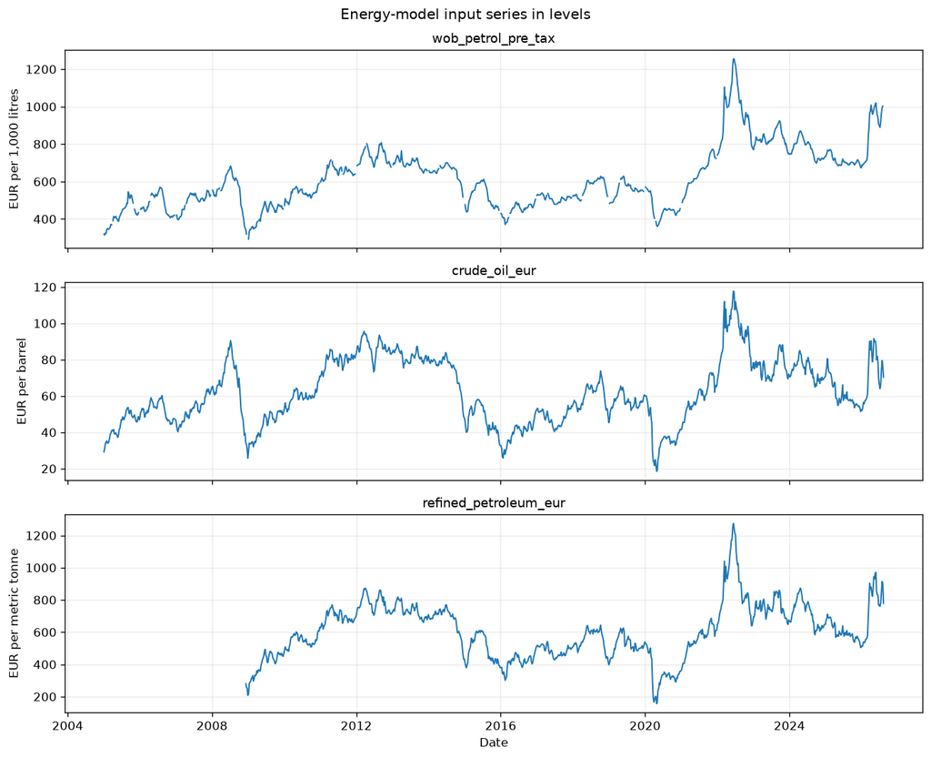

```python
# Set VINTAGE = "YYYYMMDD" to force one processed vintage.
VINTAGE = None
PROCESSED_ROOT = PROJECT_ROOT / "data" / "processed"

if VINTAGE is None:
    candidates = sorted(
        path
        for path in PROCESSED_ROOT.glob(f"*/{SPEC['dataset']}")
        if path.is_file()
    )
    if not candidates:
        raise FileNotFoundError(
            f"No {SPEC['dataset']} found below {PROCESSED_ROOT}."
        )
    COMPONENT_DATASET = candidates[-1]
else:
    COMPONENT_DATASET = PROCESSED_ROOT / VINTAGE / SPEC["dataset"]

levels = load_weekly_fuel_panel(COMPONENT_DATASET, model=MODEL)

print(f"Dataset: {COMPONENT_DATASET}")
print(f"Sample calendar: {levels.index.min().date()} to {levels.index.max().date()}")
print(f"Rows: {len(levels):,}; all dates Monday: {(levels.index.dayofweek == 0).all()}")

display(style_numeric_table(
    weekly_fuel_series_construction_table(COMPONENT_DATASET, MODEL),
    caption="Construction of the weekly petrol-model level series",
))
display(style_numeric_table(
    levels.tail(12),
    caption="Latest processed weekly levels",
))
plot_data_levels(levels, units=UNITS)
plt.show()
```

The endogenous vector is ordered from the consumer price upstream through the commodity chain:

$$ y_t= \begin{bmatrix} \Delta P_t^{\mathrm{petrol,pre\ tax}}\\ \Delta P_t^{\mathrm{crude}}\\ \Delta P_t^{\mathrm{refined\ petroleum}} \end{bmatrix}, \qquad \Delta x_t=x_t-x_{t-1}. $$

No log transformation and no seasonal dummy are used in this weekly equation.

Transformation and estimation sample

|  | value |
| --- | --- |
| missing_data_method | linear |
| missing_treatment_exact | False |
| interpolated_level_cells | 49 |
| frequency | weekly |
| calendar_rule | W-MON |
| balanced_change_start | 2008-12-15 00:00:00 |
| balanced_change_end | 2026-08-03 00:00:00 |
| balanced_changes | 921 |
| VAR_regression_observations | 897 |
| regression_columns_per_equation | 73 |
| ragged_edge_weeks | 1 |
| latest_calendar_week | 2026-08-10 00:00:00 |

Ragged-edge absolute weekly changes

| date | wob_petrol_pre_tax | crude_oil_eur | refined_petroleum_eur |
| --- | --- | --- | --- |
| 2026-08-10 | — | -5.65 | -116.06 |

Linear interpolation audit — first imputed interior levels

| date | variable | linear_imputation |
| --- | --- | --- |
| 2005-01-03 | wob_petrol_pre_tax | — |
|  | crude_oil_eur | — |
|  | refined_petroleum_eur | — |
| 2005-01-10 | wob_petrol_pre_tax | — |
|  | crude_oil_eur | — |
|  | refined_petroleum_eur | — |
| 2005-01-17 | wob_petrol_pre_tax | — |
|  | crude_oil_eur | — |
|  | refined_petroleum_eur | — |
| 2005-01-24 | wob_petrol_pre_tax | — |
|  | crude_oil_eur | — |
|  | refined_petroleum_eur | — |
| 2005-01-31 | wob_petrol_pre_tax | — |
|  | crude_oil_eur | — |
|  | refined_petroleum_eur | — |
| 2005-02-07 | wob_petrol_pre_tax | — |
|  | crude_oil_eur | — |
|  | refined_petroleum_eur | — |
| 2005-02-14 | wob_petrol_pre_tax | — |
|  | crude_oil_eur | — |
|  | refined_petroleum_eur | — |
| 2005-02-21 | wob_petrol_pre_tax | — |
|  | crude_oil_eur | — |
|  | refined_petroleum_eur | — |
| 2005-02-28 | wob_petrol_pre_tax | — |
|  | crude_oil_eur | — |
|  | refined_petroleum_eur | — |
| 2005-03-07 | wob_petrol_pre_tax | — |
|  | crude_oil_eur | — |
|  | refined_petroleum_eur | — |

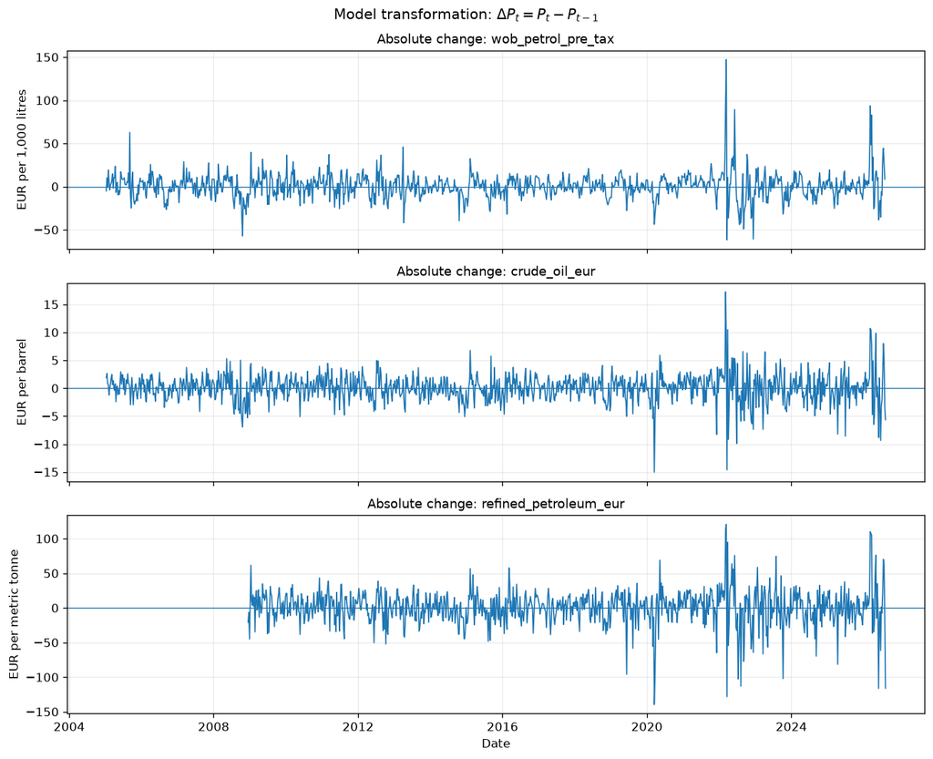

```python
prep = prepare_bvar_panel(
    levels,
    p=P,
    variables=VARIABLES,
    frequency="weekly",
    missing_data_method=MISSING_DATA_METHOD,
)

transformation_summary = pd.Series({
    "missing_data_method": prep["missing_data_method"],
    "missing_treatment_exact": prep["missing_treatment_exact"],
    "interpolated_level_cells": prep["n_interpolated_level_cells"],
    "frequency": prep["frequency"],
    "calendar_rule": prep["calendar_rule"],
    "balanced_change_start": prep["balanced_start"],
    "balanced_change_end": prep["balanced_end"],
    "balanced_changes": prep["n_balanced_changes"],
    "VAR_regression_observations": prep["n_regression_observations"],
    "regression_columns_per_equation": prep["k"],
    "ragged_edge_weeks": prep["n_ragged_periods"],
    "latest_calendar_week": prep["last_calendar_date"],
})
display(style_numeric_table(
    transformation_summary.to_frame("value"),
    caption="Transformation and estimation sample",
))
display(style_numeric_table(
    prep["ragged"],
    caption="Ragged-edge absolute weekly changes",
))

if prep.get("n_interpolated_level_cells", 0):
    linear_imputation = (
        prep["levels"]
        .where(prep["interpolated_level_mask"])
        .stack()
        .rename("linear_imputation")
        .to_frame()
    )
    linear_imputation.index.names = ["date", "variable"]
    display(style_numeric_table(
        linear_imputation.head(30),
        caption="Linear interpolation audit — first imputed interior levels",
    ))

plot_absolute_differences(prep["differences"], units=UNITS)
plt.show()
```

## 3. Priors

Prior hyperparameters

|  | value | interpretation |
| --- | --- | --- |
| lambda1 | 0.20 | overall Minnesota lag tightness |
| lambda2 | 0.50 | additional cross-lag tightness |
| lambda3 | 1.00 | lag-decay exponent |
| lambda4 | 10.00 | constant prior scale |
| A prior variance | 10.00 | variance of each free contemporaneous A coefficient |
| phi prior mean | 0.02 | prior mean of volatility-of-volatility variance |
| outlier alpha | 2.50 | Beta outlier pseudo-count |
| outlier beta | 117.50 | Beta regular-observation pseudo-count |

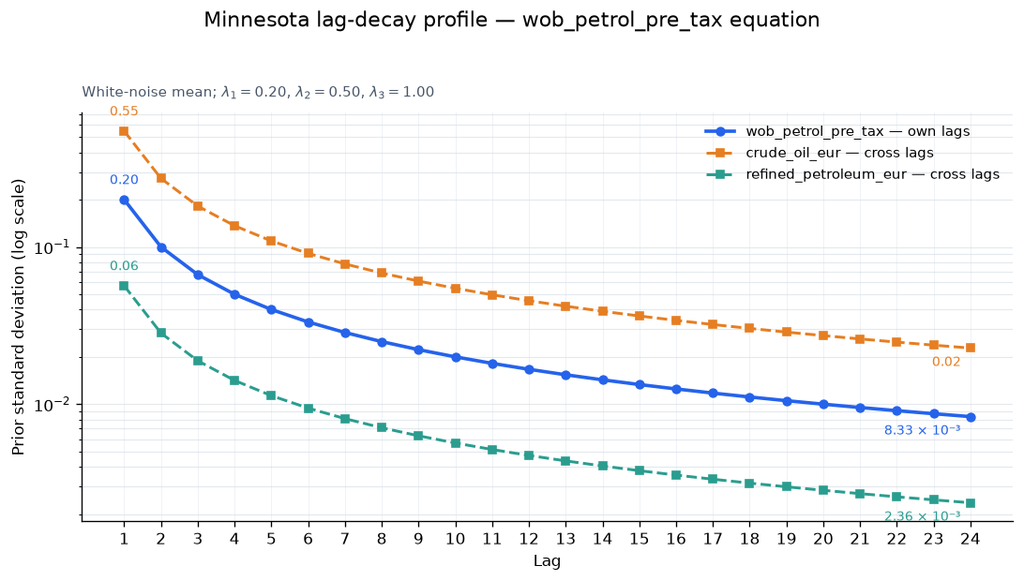

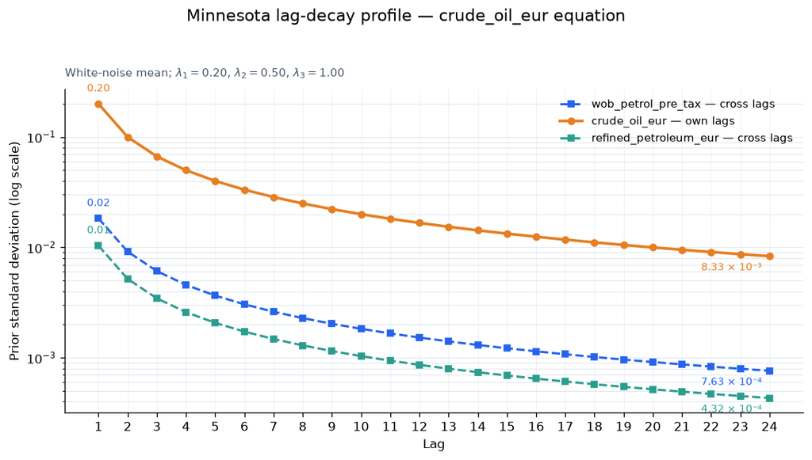

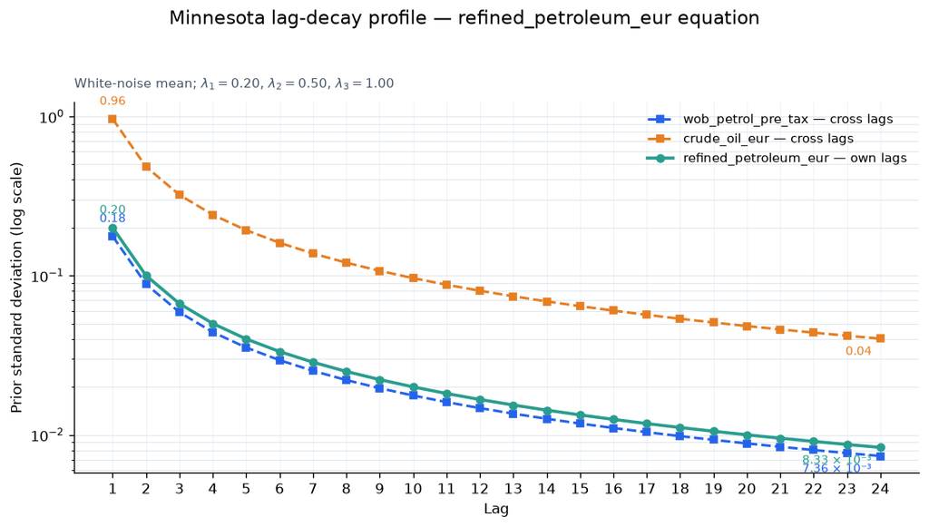

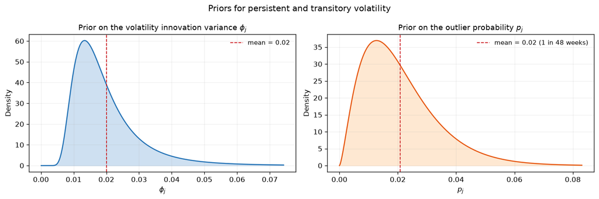

```python
prior_config = BVARSVOPriorConfig(
    lambda1=0.20,
    lambda2=0.50,
    lambda3=1.00,
    lambda4=10.0,
    a_prior_var=10.0,
    phi_prior_mean=0.02,
    phi_prior_df=10.0,
    h0_var=4.0,
    outlier_mean_frequency=1.0 / 48.0,
    outlier_prior_observations=120.0,
    outlier_grid_min=2.0,
    outlier_grid_max=20.0,
    outlier_grid_step=1.0,
    ksc_offset_scale=1e-6,
)
prior = make_bvar_svo_prior(prep, prior_config)

prior_table = pd.DataFrame({
    "value": [
        prior_config.lambda1,
        prior_config.lambda2,
        prior_config.lambda3,
        prior_config.lambda4,
        prior_config.a_prior_var,
        prior_config.phi_prior_mean,
        prior["outlier_alpha"],
        prior["outlier_beta"],
    ],
    "interpretation": [
        "overall Minnesota lag tightness",
        "additional cross-lag tightness",
        "lag-decay exponent",
        "constant prior scale",
        "variance of each free contemporaneous A coefficient",
        "prior mean of volatility-of-volatility variance",
        "Beta outlier pseudo-count",
        "Beta regular-observation pseudo-count",
    ],
}, index=[
    "lambda1", "lambda2", "lambda3", "lambda4",
    "A prior variance", "phi prior mean",
    "outlier alpha", "outlier beta",
])
display(style_numeric_table(prior_table, caption="Prior hyperparameters"))

prior_figures = plot_minnesota_prior_by_equation(prior, VARIABLES, P)
for equation, figure in prior_figures.items():
    display(figure)
    plt.close(figure)
plot_phi_and_outlier_priors(prior)
plt.show()
```

## 4. Posterior and Gibbs sampler

```python
sampler_config = SamplerConfig(
    reps=6_000,
    burn=3_000,
    thin=1,
    seed=SEED,
    max_stability_tries=1_000,
    progress_every=500,
)

result = run_energy_bvar(
    levels=levels,
    model_id=COMPONENT,
    vintage=COMPONENT_DATASET.parent.name,
    p=P,
    variables=VARIABLES,
    frequency="weekly",
    prior_config=prior_config,
    sampler_config=sampler_config,
    missing_data_method=MISSING_DATA_METHOD,
    code_version=CODE_VERSION,
)

print(f"Retained posterior draws: {result['n_draws']:,}")
print(f"Run ID: {result['metadata']['run_id']}")
print(f"Missing-data method: {result['metadata']['missing_data_method']}")
print(f"Exact missing-data treatment: {result['metadata']['missing_treatment_exact']}")
print(f"Interpolated level cells: {result['metadata']['interpolated_level_cells']}")
print(f"Frequency: {result['metadata']['frequency']}")
print(
    "B instability proposal rejection rate: "
    f"{result['B_instability_rejection_rate']:.2%}"
)
display(style_numeric_table(
    pd.Series(dict(zip(VARIABLES, result["ksc_offsets"]))).to_frame("KSC offset"),
    caption="Adaptive KSC offsets",
))

if SAVE_RESULTS:
    saved_result_paths = save_energy_bvar_result(result, RESULTS_ROOT)
    print(f"Saved run: {saved_result_paths['directory']}")
```

```
iteration 500/6,000 | B instability rejection 0.00% | radius 0.8861
iteration 1,000/6,000 | B instability rejection 0.00% | radius 0.8738
iteration 1,500/6,000 | B instability rejection 0.00% | radius 0.8797
iteration 2,000/6,000 | B instability rejection 0.00% | radius 0.8755
iteration 2,500/6,000 | B instability rejection 0.00% | radius 0.8748
iteration 3,000/6,000 | B instability rejection 0.00% | radius 0.8721
iteration 3,500/6,000 | B instability rejection 0.00% | radius 0.8812
iteration 4,000/6,000 | B instability rejection 0.00% | radius 0.8673
iteration 4,500/6,000 | B instability rejection 0.00% | radius 0.8818
iteration 5,000/6,000 | B instability rejection 0.00% | radius 0.8934
iteration 5,500/6,000 | B instability rejection 0.00% | radius 0.8858
iteration 6,000/6,000 | B instability rejection 0.00% | radius 0.8633
Retained posterior draws: 3,000
Run ID: dbb24005d734a7b037d2d885c5354ecee24101c76dca22b2acc8ef4e586e0137
Missing-data method: linear
Exact missing-data treatment: False
Interpolated level cells: 49
Frequency: weekly
B instability proposal rejection rate: 0.00%
```

Adaptive KSC offsets

|  | KSC offset |
| --- | --- |
| wob_petrol_pre_tax | 3.16 × 10⁻⁵ |
| crude_oil_eur | 1.71 × 10⁻⁶ |
| refined_petroleum_eur | 1.58 × 10⁻⁴ |

## 5. Posterior results

```
wob_petrol_pre_tax equation
```

Posterior coefficients — wob_petrol_pre_tax equation

| regressor | prior_mean | prior_sd | posterior_mean | posterior_median | posterior_sd | q05 | q16 | q84 | q95 | ESS |
| --- | --- | --- | --- | --- | --- | --- | --- | --- | --- | --- |
| const | 0.00 | 137.86 | 0.39 | 0.40 | 0.28 | -0.07 | 0.11 | 0.65 | 0.84 | 1929.91 |
| wob_petrol_pre_tax L1 | 0.00 | 0.20 | 0.18 | 0.18 | 0.04 | 0.11 | 0.14 | 0.22 | 0.25 | 1527.85 |
| crude_oil_eur L1 | 0.00 | 0.55 | 0.23 | 0.23 | 0.21 | -0.09 | 0.03 | 0.43 | 0.58 | 2010.66 |
| refined_petroleum_eur L1 | 0.00 | 0.06 | 0.13 | 0.13 | 0.02 | 0.10 | 0.11 | 0.16 | 0.17 | 1491.78 |
| wob_petrol_pre_tax L2 | 0.00 | 0.10 | 0.04 | 0.04 | 0.03 | -0.01 | 0.01 | 0.08 | 0.10 | 1977.59 |
| crude_oil_eur L2 | 0.00 | 0.27 | -0.10 | -0.10 | 0.16 | -0.36 | -0.25 | 0.06 | 0.15 | 2322.56 |
| refined_petroleum_eur L2 | 0.00 | 0.03 | 0.05 | 0.05 | 0.02 | 0.02 | 0.03 | 0.06 | 0.07 | 2198.44 |
| wob_petrol_pre_tax L3 | 0.00 | 0.07 | -0.03 | -0.03 | 0.03 | -0.08 | -0.06 | -4.06 × 10⁻³ | 0.02 | 2066.55 |
| crude_oil_eur L3 | 0.00 | 0.18 | -0.02 | -0.02 | 0.13 | -0.23 | -0.15 | 0.11 | 0.19 | 2123.16 |
| refined_petroleum_eur L3 | 0.00 | 0.02 | 0.04 | 0.04 | 0.01 | 0.02 | 0.03 | 0.05 | 0.06 | 1723.20 |
| wob_petrol_pre_tax L4 | 0.00 | 0.05 | -0.03 | -0.03 | 0.02 | -0.07 | -0.05 | -5.16 × 10⁻³ | 0.01 | 2160.04 |
| crude_oil_eur L4 | 0.00 | 0.14 | 0.06 | 0.06 | 0.11 | -0.11 | -0.04 | 0.17 | 0.24 | 2272.77 |
| refined_petroleum_eur L4 | 0.00 | 0.01 | 0.01 | 0.01 | 0.01 | -4.32 × 10⁻³ | 3.53 × 10⁻³ | 0.03 | 0.03 | 2102.59 |
| wob_petrol_pre_tax L5 | 0.00 | 0.04 | 0.01 | 0.01 | 0.02 | -0.03 | -0.01 | 0.03 | 0.05 | 2184.54 |
| crude_oil_eur L5 | 0.00 | 0.11 | 0.18 | 0.18 | 0.09 | 0.03 | 0.09 | 0.26 | 0.32 | 2805.64 |
| refined_petroleum_eur L5 | 0.00 | 0.01 | 0.01 | 0.01 | 9.56 × 10⁻³ | -1.82 × 10⁻³ | 4.14 × 10⁻³ | 0.02 | 0.03 | 2156.50 |
| wob_petrol_pre_tax L6 | 0.00 | 0.03 | -7.70 × 10⁻³ | -7.75 × 10⁻³ | 0.02 | -0.04 | -0.03 | 0.01 | 0.03 | 2081.27 |
| crude_oil_eur L6 | 0.00 | 0.09 | 0.06 | 0.06 | 0.08 | -0.07 | -0.02 | 0.14 | 0.19 | 2458.85 |
| refined_petroleum_eur L6 | 0.00 | 9.44 × 10⁻³ | 6.64 × 10⁻³ | 6.55 × 10⁻³ | 7.92 × 10⁻³ | -6.36 × 10⁻³ | -1.26 × 10⁻³ | 0.01 | 0.02 | 2770.69 |
| wob_petrol_pre_tax L7 | 0.00 | 0.03 | 9.60 × 10⁻³ | 9.51 × 10⁻³ | 0.02 | -0.02 | -9.65 × 10⁻³ | 0.03 | 0.04 | 2526.97 |
| crude_oil_eur L7 | 0.00 | 0.08 | 0.03 | 0.02 | 0.07 | -0.09 | -0.04 | 0.09 | 0.13 | 2598.18 |
| refined_petroleum_eur L7 | 0.00 | 8.09 × 10⁻³ | 3.07 × 10⁻³ | 3.11 × 10⁻³ | 7.21 × 10⁻³ | -8.90 × 10⁻³ | -4.15 × 10⁻³ | 0.01 | 0.01 | 2820.39 |
| wob_petrol_pre_tax L8 | 0.00 | 0.03 | 2.61 × 10⁻³ | 2.49 × 10⁻³ | 0.02 | -0.03 | -0.02 | 0.02 | 0.03 | 2020.73 |
| crude_oil_eur L8 | 0.00 | 0.07 | 0.01 | 0.01 | 0.06 | -0.09 | -0.05 | 0.07 | 0.12 | 1991.14 |
| refined_petroleum_eur L8 | 0.00 | 7.08 × 10⁻³ | 3.55 × 10⁻³ | 3.70 × 10⁻³ | 6.26 × 10⁻³ | -6.64 × 10⁻³ | -2.79 × 10⁻³ | 9.84 × 10⁻³ | 0.01 | 3000.00 |
| wob_petrol_pre_tax L9 | 0.00 | 0.02 | 1.22 × 10⁻³ | 9.70 × 10⁻⁴ | 0.02 | -0.03 | -0.01 | 0.02 | 0.03 | 2119.57 |
| crude_oil_eur L9 | 0.00 | 0.06 | -0.02 | -0.02 | 0.06 | -0.11 | -0.08 | 0.03 | 0.07 | 3000.00 |
| refined_petroleum_eur L9 | 0.00 | 6.29 × 10⁻³ | -9.09 × 10⁻⁴ | -1.01 × 10⁻³ | 5.62 × 10⁻³ | -0.01 | -6.43 × 10⁻³ | 4.68 × 10⁻³ | 8.56 × 10⁻³ | 2916.98 |
| wob_petrol_pre_tax L10 | 0.00 | 0.02 | -0.02 | -0.02 | 0.02 | -0.04 | -0.03 | -2.72 × 10⁻³ | 7.38 × 10⁻³ | 2305.07 |
| crude_oil_eur L10 | 0.00 | 0.05 | -4.63 × 10⁻³ | -4.72 × 10⁻³ | 0.05 | -0.09 | -0.05 | 0.05 | 0.08 | 2558.73 |
| refined_petroleum_eur L10 | 0.00 | 5.66 × 10⁻³ | -2.46 × 10⁻³ | -2.56 × 10⁻³ | 5.22 × 10⁻³ | -0.01 | -7.53 × 10⁻³ | 2.61 × 10⁻³ | 6.34 × 10⁻³ | 2621.73 |
| wob_petrol_pre_tax L11 | 0.00 | 0.02 | 2.78 × 10⁻³ | 2.54 × 10⁻³ | 0.01 | -0.02 | -0.01 | 0.02 | 0.03 | 2324.84 |
| crude_oil_eur L11 | 0.00 | 0.05 | 2.48 × 10⁻⁴ | -7.48 × 10⁻⁴ | 0.05 | -0.08 | -0.04 | 0.05 | 0.08 | 2515.52 |
| refined_petroleum_eur L11 | 0.00 | 5.15 × 10⁻³ | 1.03 × 10⁻³ | 1.05 × 10⁻³ | 4.66 × 10⁻³ | -6.57 × 10⁻³ | -3.70 × 10⁻³ | 5.66 × 10⁻³ | 8.60 × 10⁻³ | 2818.64 |
| wob_petrol_pre_tax L12 | 0.00 | 0.02 | 0.01 | 0.01 | 0.01 | -9.70 × 10⁻³ | -1.12 × 10⁻³ | 0.03 | 0.03 | 2265.31 |
| crude_oil_eur L12 | 0.00 | 0.05 | -0.01 | -0.02 | 0.04 | -0.08 | -0.06 | 0.03 | 0.06 | 3000.00 |
| refined_petroleum_eur L12 | 0.00 | 4.72 × 10⁻³ | 1.41 × 10⁻³ | 1.31 × 10⁻³ | 4.40 × 10⁻³ | -6.02 × 10⁻³ | -2.84 × 10⁻³ | 5.64 × 10⁻³ | 8.92 × 10⁻³ | 2708.55 |
| wob_petrol_pre_tax L13 | 0.00 | 0.02 | -0.01 | -0.01 | 0.01 | -0.03 | -0.02 | 2.33 × 10⁻³ | 0.01 | 2633.12 |
| crude_oil_eur L13 | 0.00 | 0.04 | -9.44 × 10⁻³ | -9.11 × 10⁻³ | 0.04 | -0.07 | -0.05 | 0.03 | 0.06 | 2381.67 |
| refined_petroleum_eur L13 | 0.00 | 4.36 × 10⁻³ | -6.33 × 10⁻⁴ | -6.51 × 10⁻⁴ | 4.14 × 10⁻³ | -7.49 × 10⁻³ | -4.72 × 10⁻³ | 3.59 × 10⁻³ | 6.10 × 10⁻³ | 2476.42 |
| wob_petrol_pre_tax L14 | 0.00 | 0.01 | 2.90 × 10⁻⁴ | 4.17 × 10⁻⁴ | 0.01 | -0.02 | -0.01 | 0.01 | 0.02 | 3000.00 |
| crude_oil_eur L14 | 0.00 | 0.04 | -4.40 × 10⁻³ | -4.42 × 10⁻³ | 0.04 | -0.07 | -0.04 | 0.03 | 0.06 | 2902.15 |
| refined_petroleum_eur L14 | 0.00 | 4.04 × 10⁻³ | 6.65 × 10⁻⁵ | 1.14 × 10⁻⁴ | 3.86 × 10⁻³ | -6.35 × 10⁻³ | -3.78 × 10⁻³ | 3.83 × 10⁻³ | 6.45 × 10⁻³ | 2694.81 |
| wob_petrol_pre_tax L15 | 0.00 | 0.01 | -8.88 × 10⁻³ | -8.69 × 10⁻³ | 0.01 | -0.03 | -0.02 | 2.00 × 10⁻³ | 9.14 × 10⁻³ | 2777.47 |
| crude_oil_eur L15 | 0.00 | 0.04 | -0.01 | -0.01 | 0.04 | -0.07 | -0.05 | 0.02 | 0.05 | 2923.84 |
| refined_petroleum_eur L15 | 0.00 | 3.78 × 10⁻³ | -5.15 × 10⁻⁴ | -5.34 × 10⁻⁴ | 3.62 × 10⁻³ | -6.42 × 10⁻³ | -4.07 × 10⁻³ | 3.08 × 10⁻³ | 5.50 × 10⁻³ | 2948.60 |
| wob_petrol_pre_tax L16 | 0.00 | 0.01 | -1.89 × 10⁻³ | -1.86 × 10⁻³ | 0.01 | -0.02 | -0.01 | 8.98 × 10⁻³ | 0.02 | 2539.22 |
| crude_oil_eur L16 | 0.00 | 0.03 | -4.39 × 10⁻³ | -4.61 × 10⁻³ | 0.03 | -0.06 | -0.04 | 0.03 | 0.05 | 2826.29 |
| refined_petroleum_eur L16 | 0.00 | 3.54 × 10⁻³ | 1.31 × 10⁻⁴ | 1.12 × 10⁻⁴ | 3.39 × 10⁻³ | -5.41 × 10⁻³ | -3.23 × 10⁻³ | 3.52 × 10⁻³ | 5.57 × 10⁻³ | 2860.68 |
| wob_petrol_pre_tax L17 | 0.00 | 0.01 | -3.63 × 10⁻³ | -3.71 × 10⁻³ | 0.01 | -0.02 | -0.01 | 6.65 × 10⁻³ | 0.01 | 2727.67 |
| crude_oil_eur L17 | 0.00 | 0.03 | 6.17 × 10⁻³ | 6.11 × 10⁻³ | 0.03 | -0.04 | -0.03 | 0.04 | 0.06 | 2988.63 |
| refined_petroleum_eur L17 | 0.00 | 3.33 × 10⁻³ | 2.93 × 10⁻⁴ | 2.95 × 10⁻⁴ | 3.22 × 10⁻³ | -5.00 × 10⁻³ | -2.95 × 10⁻³ | 3.49 × 10⁻³ | 5.57 × 10⁻³ | 2990.28 |
| wob_petrol_pre_tax L18 | 0.00 | 0.01 | 4.76 × 10⁻³ | 4.87 × 10⁻³ | 9.92 × 10⁻³ | -0.01 | -5.25 × 10⁻³ | 0.01 | 0.02 | 2460.44 |
| crude_oil_eur L18 | 0.00 | 0.03 | 2.46 × 10⁻³ | 2.61 × 10⁻³ | 0.03 | -0.05 | -0.03 | 0.03 | 0.05 | 2843.85 |
| refined_petroleum_eur L18 | 0.00 | 3.15 × 10⁻³ | 1.05 × 10⁻³ | 1.12 × 10⁻³ | 3.04 × 10⁻³ | -3.99 × 10⁻³ | -1.96 × 10⁻³ | 4.02 × 10⁻³ | 6.07 × 10⁻³ | 3000.00 |
| wob_petrol_pre_tax L19 | 0.00 | 0.01 | 6.36 × 10⁻⁴ | 6.62 × 10⁻⁴ | 9.49 × 10⁻³ | -0.01 | -8.88 × 10⁻³ | 0.01 | 0.02 | 2847.36 |
| crude_oil_eur L19 | 0.00 | 0.03 | -5.61 × 10⁻³ | -5.59 × 10⁻³ | 0.03 | -0.05 | -0.03 | 0.02 | 0.04 | 2769.35 |
| refined_petroleum_eur L19 | 0.00 | 2.98 × 10⁻³ | -2.25 × 10⁻⁴ | -1.88 × 10⁻⁴ | 2.91 × 10⁻³ | -4.90 × 10⁻³ | -3.20 × 10⁻³ | 2.68 × 10⁻³ | 4.57 × 10⁻³ | 2883.42 |
| wob_petrol_pre_tax L20 | 0.00 | 0.01 | 5.91 × 10⁻⁴ | 5.84 × 10⁻⁴ | 8.66 × 10⁻³ | -0.01 | -8.01 × 10⁻³ | 9.22 × 10⁻³ | 0.01 | 2425.08 |
| crude_oil_eur L20 | 0.00 | 0.03 | 4.85 × 10⁻⁴ | 8.82 × 10⁻⁵ | 0.03 | -0.04 | -0.03 | 0.03 | 0.04 | 2891.34 |
| refined_petroleum_eur L20 | 0.00 | 2.83 × 10⁻³ | 1.18 × 10⁻⁴ | 1.83 × 10⁻⁴ | 2.72 × 10⁻³ | -4.48 × 10⁻³ | -2.56 × 10⁻³ | 2.82 × 10⁻³ | 4.65 × 10⁻³ | 2950.19 |
| wob_petrol_pre_tax L21 | 0.00 | 9.52 × 10⁻³ | 1.31 × 10⁻³ | 1.41 × 10⁻³ | 8.76 × 10⁻³ | -0.01 | -7.46 × 10⁻³ | 9.92 × 10⁻³ | 0.02 | 2387.82 |
| crude_oil_eur L21 | 0.00 | 0.03 | -3.16 × 10⁻³ | -2.80 × 10⁻³ | 0.03 | -0.05 | -0.03 | 0.02 | 0.04 | 2932.32 |
| refined_petroleum_eur L21 | 0.00 | 2.70 × 10⁻³ | -2.10 × 10⁻⁴ | -2.64 × 10⁻⁴ | 2.61 × 10⁻³ | -4.42 × 10⁻³ | -2.87 × 10⁻³ | 2.34 × 10⁻³ | 4.17 × 10⁻³ | 2796.85 |
| wob_petrol_pre_tax L22 | 0.00 | 9.09 × 10⁻³ | 1.48 × 10⁻³ | 1.50 × 10⁻³ | 8.34 × 10⁻³ | -0.01 | -6.80 × 10⁻³ | 9.78 × 10⁻³ | 0.02 | 2752.59 |
| crude_oil_eur L22 | 0.00 | 0.02 | 1.68 × 10⁻³ | 2.24 × 10⁻³ | 0.02 | -0.04 | -0.02 | 0.03 | 0.04 | 3000.00 |
| refined_petroleum_eur L22 | 0.00 | 2.57 × 10⁻³ | 2.23 × 10⁻⁴ | 1.96 × 10⁻⁴ | 2.50 × 10⁻³ | -3.79 × 10⁻³ | -2.24 × 10⁻³ | 2.72 × 10⁻³ | 4.32 × 10⁻³ | 2740.76 |
| wob_petrol_pre_tax L23 | 0.00 | 8.70 × 10⁻³ | 1.38 × 10⁻³ | 1.54 × 10⁻³ | 7.83 × 10⁻³ | -0.01 | -6.22 × 10⁻³ | 9.31 × 10⁻³ | 0.01 | 2699.18 |
| crude_oil_eur L23 | 0.00 | 0.02 | -7.22 × 10⁻³ | -7.23 × 10⁻³ | 0.02 | -0.05 | -0.03 | 0.01 | 0.03 | 2812.75 |
| refined_petroleum_eur L23 | 0.00 | 2.46 × 10⁻³ | -3.72 × 10⁻⁵ | -3.90 × 10⁻⁵ | 2.42 × 10⁻³ | -4.01 × 10⁻³ | -2.48 × 10⁻³ | 2.35 × 10⁻³ | 3.96 × 10⁻³ | 3000.00 |
| wob_petrol_pre_tax L24 | 0.00 | 8.33 × 10⁻³ | 1.70 × 10⁻⁵ | 5.72 × 10⁻⁵ | 7.46 × 10⁻³ | -0.01 | -7.39 × 10⁻³ | 7.33 × 10⁻³ | 0.01 | 2816.59 |
| crude_oil_eur L24 | 0.00 | 0.02 | -2.88 × 10⁻³ | -3.75 × 10⁻³ | 0.02 | -0.04 | -0.02 | 0.02 | 0.04 | 2803.37 |
| refined_petroleum_eur L24 | 0.00 | 2.36 × 10⁻³ | -9.06 × 10⁻⁵ | -1.01 × 10⁻⁴ | 2.27 × 10⁻³ | -3.80 × 10⁻³ | -2.39 × 10⁻³ | 2.18 × 10⁻³ | 3.64 × 10⁻³ | 2873.12 |

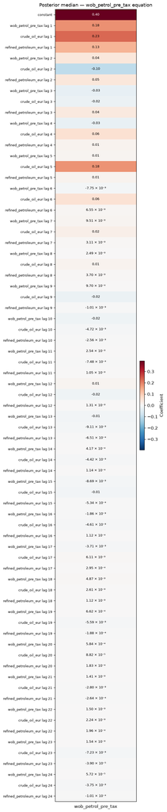

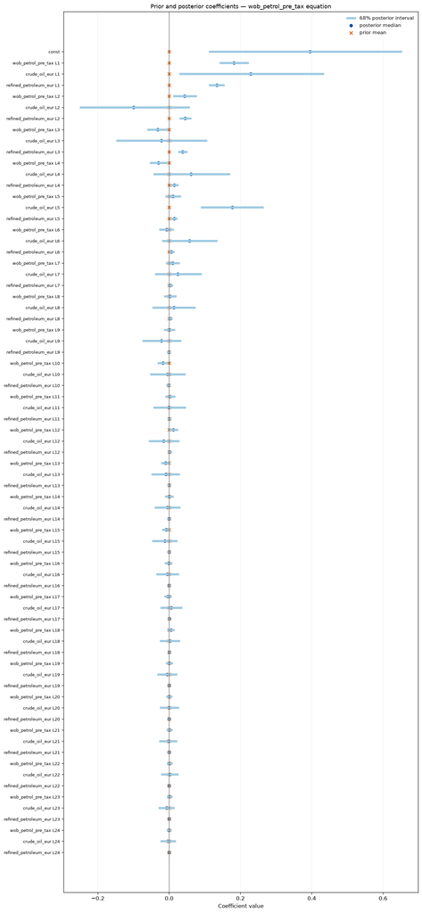

```
crude_oil_eur equation
```

Posterior coefficients — crude_oil_eur equation

| regressor | prior_mean | prior_sd | posterior_mean | posterior_median | posterior_sd | q05 | q16 | q84 | q95 | ESS |
| --- | --- | --- | --- | --- | --- | --- | --- | --- | --- | --- |
| const | 0.00 | 25.25 | 0.07 | 0.07 | 0.06 | -0.04 | 9.13 × 10⁻³ | 0.13 | 0.17 | 1908.84 |
| wob_petrol_pre_tax L1 | 0.00 | 0.02 | 0.04 | 0.04 | 8.02 × 10⁻³ | 0.02 | 0.03 | 0.05 | 0.05 | 1944.67 |
| crude_oil_eur L1 | 0.00 | 0.20 | 0.14 | 0.14 | 0.05 | 0.06 | 0.09 | 0.18 | 0.21 | 2065.41 |
| refined_petroleum_eur L1 | 0.00 | 0.01 | -9.15 × 10⁻³ | -9.17 × 10⁻³ | 4.73 × 10⁻³ | -0.02 | -0.01 | -4.46 × 10⁻³ | -1.48 × 10⁻³ | 1734.22 |
| wob_petrol_pre_tax L2 | 0.00 | 9.16 × 10⁻³ | 6.30 × 10⁻³ | 6.26 × 10⁻³ | 5.79 × 10⁻³ | -3.13 × 10⁻³ | 8.02 × 10⁻⁴ | 0.01 | 0.02 | 1976.61 |
| crude_oil_eur L2 | 0.00 | 0.10 | -0.07 | -0.07 | 0.04 | -0.13 | -0.11 | -0.03 | -0.01 | 2092.04 |
| refined_petroleum_eur L2 | 0.00 | 5.19 × 10⁻³ | -1.07 × 10⁻³ | -1.09 × 10⁻³ | 3.38 × 10⁻³ | -6.54 × 10⁻³ | -4.35 × 10⁻³ | 2.31 × 10⁻³ | 4.46 × 10⁻³ | 2561.15 |
| wob_petrol_pre_tax L3 | 0.00 | 6.10 × 10⁻³ | -6.69 × 10⁻³ | -6.79 × 10⁻³ | 4.44 × 10⁻³ | -0.01 | -0.01 | -2.25 × 10⁻³ | 7.42 × 10⁻⁴ | 2051.46 |
| crude_oil_eur L3 | 0.00 | 0.07 | 1.96 × 10⁻³ | 1.87 × 10⁻³ | 0.03 | -0.05 | -0.03 | 0.03 | 0.05 | 1608.36 |
| refined_petroleum_eur L3 | 0.00 | 3.46 × 10⁻³ | -3.96 × 10⁻³ | -4.04 × 10⁻³ | 2.69 × 10⁻³ | -8.35 × 10⁻³ | -6.63 × 10⁻³ | -1.34 × 10⁻³ | 5.79 × 10⁻⁴ | 2487.53 |
| wob_petrol_pre_tax L4 | 0.00 | 4.58 × 10⁻³ | 4.19 × 10⁻³ | 4.22 × 10⁻³ | 3.62 × 10⁻³ | -1.92 × 10⁻³ | 5.56 × 10⁻⁴ | 7.85 × 10⁻³ | 0.01 | 2242.35 |
| crude_oil_eur L4 | 0.00 | 0.05 | -0.02 | -0.02 | 0.03 | -0.06 | -0.04 | 0.01 | 0.03 | 2323.72 |
| refined_petroleum_eur L4 | 0.00 | 2.59 × 10⁻³ | -2.29 × 10⁻³ | -2.29 × 10⁻³ | 2.20 × 10⁻³ | -5.95 × 10⁻³ | -4.41 × 10⁻³ | -1.84 × 10⁻⁴ | 1.29 × 10⁻³ | 2527.46 |
| wob_petrol_pre_tax L5 | 0.00 | 3.66 × 10⁻³ | 4.65 × 10⁻⁴ | 4.26 × 10⁻⁴ | 3.02 × 10⁻³ | -4.57 × 10⁻³ | -2.53 × 10⁻³ | 3.39 × 10⁻³ | 5.41 × 10⁻³ | 2744.03 |
| crude_oil_eur L5 | 0.00 | 0.04 | -9.57 × 10⁻³ | -9.47 × 10⁻³ | 0.02 | -0.05 | -0.03 | 0.01 | 0.03 | 2265.16 |
| refined_petroleum_eur L5 | 0.00 | 2.07 × 10⁻³ | 2.93 × 10⁻⁴ | 2.86 × 10⁻⁴ | 1.81 × 10⁻³ | -2.64 × 10⁻³ | -1.52 × 10⁻³ | 2.07 × 10⁻³ | 3.26 × 10⁻³ | 2380.51 |
| wob_petrol_pre_tax L6 | 0.00 | 3.05 × 10⁻³ | 1.54 × 10⁻⁴ | 1.68 × 10⁻⁴ | 2.66 × 10⁻³ | -4.18 × 10⁻³ | -2.47 × 10⁻³ | 2.78 × 10⁻³ | 4.58 × 10⁻³ | 2848.29 |
| crude_oil_eur L6 | 0.00 | 0.03 | -5.20 × 10⁻³ | -5.45 × 10⁻³ | 0.02 | -0.04 | -0.03 | 0.02 | 0.03 | 2294.36 |
| refined_petroleum_eur L6 | 0.00 | 1.73 × 10⁻³ | 9.81 × 10⁻⁴ | 9.92 × 10⁻⁴ | 1.53 × 10⁻³ | -1.48 × 10⁻³ | -5.80 × 10⁻⁴ | 2.51 × 10⁻³ | 3.48 × 10⁻³ | 2176.36 |
| wob_petrol_pre_tax L7 | 0.00 | 2.62 × 10⁻³ | 6.43 × 10⁻⁴ | 6.58 × 10⁻⁴ | 2.31 × 10⁻³ | -3.27 × 10⁻³ | -1.68 × 10⁻³ | 2.93 × 10⁻³ | 4.47 × 10⁻³ | 3000.00 |
| crude_oil_eur L7 | 0.00 | 0.03 | -0.02 | -0.02 | 0.02 | -0.05 | -0.04 | -4.24 × 10⁻³ | 7.82 × 10⁻³ | 2676.89 |
| refined_petroleum_eur L7 | 0.00 | 1.48 × 10⁻³ | 6.32 × 10⁻⁴ | 6.36 × 10⁻⁴ | 1.33 × 10⁻³ | -1.54 × 10⁻³ | -7.06 × 10⁻⁴ | 1.94 × 10⁻³ | 2.80 × 10⁻³ | 2974.77 |
| wob_petrol_pre_tax L8 | 0.00 | 2.29 × 10⁻³ | 6.67 × 10⁻⁵ | 1.05 × 10⁻⁴ | 2.04 × 10⁻³ | -3.27 × 10⁻³ | -2.00 × 10⁻³ | 2.08 × 10⁻³ | 3.36 × 10⁻³ | 2157.26 |
| crude_oil_eur L8 | 0.00 | 0.03 | 0.02 | 0.02 | 0.02 | -5.17 × 10⁻³ | 6.37 × 10⁻³ | 0.04 | 0.05 | 2691.85 |
| refined_petroleum_eur L8 | 0.00 | 1.30 × 10⁻³ | -3.03 × 10⁻⁵ | -3.99 × 10⁻⁵ | 1.18 × 10⁻³ | -1.91 × 10⁻³ | -1.22 × 10⁻³ | 1.16 × 10⁻³ | 1.91 × 10⁻³ | 2610.05 |
| wob_petrol_pre_tax L9 | 0.00 | 2.03 × 10⁻³ | -4.07 × 10⁻⁴ | -4.83 × 10⁻⁴ | 1.86 × 10⁻³ | -3.45 × 10⁻³ | -2.25 × 10⁻³ | 1.45 × 10⁻³ | 2.68 × 10⁻³ | 2837.44 |
| crude_oil_eur L9 | 0.00 | 0.02 | -9.18 × 10⁻³ | -8.78 × 10⁻³ | 0.02 | -0.04 | -0.03 | 7.03 × 10⁻³ | 0.02 | 2476.37 |
| refined_petroleum_eur L9 | 0.00 | 1.15 × 10⁻³ | -3.41 × 10⁻⁴ | -3.29 × 10⁻⁴ | 1.08 × 10⁻³ | -2.12 × 10⁻³ | -1.45 × 10⁻³ | 7.46 × 10⁻⁴ | 1.38 × 10⁻³ | 2990.52 |
| wob_petrol_pre_tax L10 | 0.00 | 1.83 × 10⁻³ | -8.18 × 10⁻⁶ | -9.48 × 10⁻⁷ | 1.67 × 10⁻³ | -2.72 × 10⁻³ | -1.71 × 10⁻³ | 1.68 × 10⁻³ | 2.73 × 10⁻³ | 1920.21 |
| crude_oil_eur L10 | 0.00 | 0.02 | -0.01 | -0.01 | 0.02 | -0.04 | -0.03 | 1.91 × 10⁻³ | 0.01 | 2839.64 |
| refined_petroleum_eur L10 | 0.00 | 1.04 × 10⁻³ | 1.68 × 10⁻⁴ | 1.66 × 10⁻⁴ | 9.60 × 10⁻⁴ | -1.44 × 10⁻³ | -7.69 × 10⁻⁴ | 1.10 × 10⁻³ | 1.73 × 10⁻³ | 3000.00 |
| wob_petrol_pre_tax L11 | 0.00 | 1.66 × 10⁻³ | -5.06 × 10⁻⁴ | -5.00 × 10⁻⁴ | 1.55 × 10⁻³ | -3.10 × 10⁻³ | -2.03 × 10⁻³ | 1.03 × 10⁻³ | 1.98 × 10⁻³ | 2332.84 |
| crude_oil_eur L11 | 0.00 | 0.02 | -1.76 × 10⁻³ | -1.65 × 10⁻³ | 0.01 | -0.02 | -0.02 | 0.01 | 0.02 | 2295.70 |
| refined_petroleum_eur L11 | 0.00 | 9.43 × 10⁻⁴ | -1.79 × 10⁻⁴ | -1.93 × 10⁻⁴ | 8.72 × 10⁻⁴ | -1.60 × 10⁻³ | -1.04 × 10⁻³ | 6.95 × 10⁻⁴ | 1.28 × 10⁻³ | 2397.72 |
| wob_petrol_pre_tax L12 | 0.00 | 1.53 × 10⁻³ | -2.48 × 10⁻⁴ | -2.24 × 10⁻⁴ | 1.43 × 10⁻³ | -2.54 × 10⁻³ | -1.65 × 10⁻³ | 1.16 × 10⁻³ | 2.08 × 10⁻³ | 2720.83 |
| crude_oil_eur L12 | 0.00 | 0.02 | -4.18 × 10⁻³ | -4.66 × 10⁻³ | 0.01 | -0.03 | -0.02 | 8.83 × 10⁻³ | 0.02 | 2858.12 |
| refined_petroleum_eur L12 | 0.00 | 8.64 × 10⁻⁴ | -1.92 × 10⁻⁴ | -1.74 × 10⁻⁴ | 8.01 × 10⁻⁴ | -1.56 × 10⁻³ | -9.90 × 10⁻⁴ | 5.80 × 10⁻⁴ | 1.11 × 10⁻³ | 2856.03 |
| wob_petrol_pre_tax L13 | 0.00 | 1.41 × 10⁻³ | 6.15 × 10⁻⁴ | 6.19 × 10⁻⁴ | 1.33 × 10⁻³ | -1.64 × 10⁻³ | -6.50 × 10⁻⁴ | 1.95 × 10⁻³ | 2.76 × 10⁻³ | 2363.04 |
| crude_oil_eur L13 | 0.00 | 0.02 | -2.46 × 10⁻³ | -2.23 × 10⁻³ | 0.01 | -0.02 | -0.01 | 9.42 × 10⁻³ | 0.02 | 2852.60 |
| refined_petroleum_eur L13 | 0.00 | 7.98 × 10⁻⁴ | -1.75 × 10⁻⁴ | -1.72 × 10⁻⁴ | 7.59 × 10⁻⁴ | -1.43 × 10⁻³ | -9.22 × 10⁻⁴ | 5.71 × 10⁻⁴ | 1.07 × 10⁻³ | 2876.18 |
| wob_petrol_pre_tax L14 | 0.00 | 1.31 × 10⁻³ | 3.62 × 10⁻⁵ | 2.49 × 10⁻⁵ | 1.23 × 10⁻³ | -1.94 × 10⁻³ | -1.18 × 10⁻³ | 1.27 × 10⁻³ | 2.07 × 10⁻³ | 2792.60 |
| crude_oil_eur L14 | 0.00 | 0.01 | 4.03 × 10⁻³ | 4.09 × 10⁻³ | 0.01 | -0.02 | -7.84 × 10⁻³ | 0.02 | 0.02 | 2291.01 |
| refined_petroleum_eur L14 | 0.00 | 7.41 × 10⁻⁴ | 8.96 × 10⁻⁵ | 8.49 × 10⁻⁵ | 7.06 × 10⁻⁴ | -1.06 × 10⁻³ | -6.08 × 10⁻⁴ | 7.76 × 10⁻⁴ | 1.25 × 10⁻³ | 2906.81 |
| wob_petrol_pre_tax L15 | 0.00 | 1.22 × 10⁻³ | -4.30 × 10⁻⁵ | -4.68 × 10⁻⁵ | 1.17 × 10⁻³ | -1.92 × 10⁻³ | -1.22 × 10⁻³ | 1.10 × 10⁻³ | 1.89 × 10⁻³ | 3000.00 |
| crude_oil_eur L15 | 0.00 | 0.01 | -0.01 | -0.01 | 0.01 | -0.03 | -0.02 | 6.89 × 10⁻⁴ | 8.05 × 10⁻³ | 2406.86 |
| refined_petroleum_eur L15 | 0.00 | 6.91 × 10⁻⁴ | -1.32 × 10⁻⁴ | -1.27 × 10⁻⁴ | 6.57 × 10⁻⁴ | -1.24 × 10⁻³ | -7.92 × 10⁻⁴ | 5.31 × 10⁻⁴ | 9.19 × 10⁻⁴ | 3000.00 |
| wob_petrol_pre_tax L16 | 0.00 | 1.14 × 10⁻³ | -3.06 × 10⁻⁴ | -3.12 × 10⁻⁴ | 1.11 × 10⁻³ | -2.14 × 10⁻³ | -1.41 × 10⁻³ | 7.93 × 10⁻⁴ | 1.51 × 10⁻³ | 3000.00 |
| crude_oil_eur L16 | 0.00 | 0.01 | -1.90 × 10⁻³ | -1.78 × 10⁻³ | 0.01 | -0.02 | -0.01 | 8.33 × 10⁻³ | 0.02 | 2796.27 |
| refined_petroleum_eur L16 | 0.00 | 6.48 × 10⁻⁴ | -9.33 × 10⁻⁵ | -7.17 × 10⁻⁵ | 6.24 × 10⁻⁴ | -1.12 × 10⁻³ | -7.24 × 10⁻⁴ | 5.20 × 10⁻⁴ | 9.25 × 10⁻⁴ | 2294.56 |
| wob_petrol_pre_tax L17 | 0.00 | 1.08 × 10⁻³ | 2.73 × 10⁻⁴ | 2.90 × 10⁻⁴ | 1.04 × 10⁻³ | -1.44 × 10⁻³ | -7.62 × 10⁻⁴ | 1.31 × 10⁻³ | 1.97 × 10⁻³ | 1791.13 |
| crude_oil_eur L17 | 0.00 | 0.01 | 1.45 × 10⁻³ | 1.47 × 10⁻³ | 9.82 × 10⁻³ | -0.02 | -8.02 × 10⁻³ | 0.01 | 0.02 | 2533.19 |
| refined_petroleum_eur L17 | 0.00 | 6.10 × 10⁻⁴ | 1.03 × 10⁻⁴ | 1.05 × 10⁻⁴ | 5.89 × 10⁻⁴ | -8.81 × 10⁻⁴ | -4.77 × 10⁻⁴ | 6.99 × 10⁻⁴ | 1.07 × 10⁻³ | 3000.00 |
| wob_petrol_pre_tax L18 | 0.00 | 1.02 × 10⁻³ | 6.59 × 10⁻⁵ | 7.44 × 10⁻⁵ | 9.59 × 10⁻⁴ | -1.53 × 10⁻³ | -9.12 × 10⁻⁴ | 9.91 × 10⁻⁴ | 1.62 × 10⁻³ | 2816.16 |
| crude_oil_eur L18 | 0.00 | 0.01 | -4.99 × 10⁻³ | -5.17 × 10⁻³ | 9.54 × 10⁻³ | -0.02 | -0.01 | 4.39 × 10⁻³ | 0.01 | 2628.92 |
| refined_petroleum_eur L18 | 0.00 | 5.76 × 10⁻⁴ | -1.20 × 10⁻⁴ | -1.13 × 10⁻⁴ | 5.41 × 10⁻⁴ | -1.02 × 10⁻³ | -6.76 × 10⁻⁴ | 4.16 × 10⁻⁴ | 7.47 × 10⁻⁴ | 3000.00 |
| wob_petrol_pre_tax L19 | 0.00 | 9.64 × 10⁻⁴ | -4.48 × 10⁻⁵ | -5.01 × 10⁻⁵ | 9.36 × 10⁻⁴ | -1.60 × 10⁻³ | -9.50 × 10⁻⁴ | 8.85 × 10⁻⁴ | 1.52 × 10⁻³ | 3000.00 |
| crude_oil_eur L19 | 0.00 | 0.01 | -5.14 × 10⁻³ | -5.02 × 10⁻³ | 9.18 × 10⁻³ | -0.02 | -0.01 | 3.80 × 10⁻³ | 0.01 | 2316.03 |
| refined_petroleum_eur L19 | 0.00 | 5.46 × 10⁻⁴ | 3.60 × 10⁻⁵ | 2.70 × 10⁻⁵ | 5.15 × 10⁻⁴ | -8.04 × 10⁻⁴ | -4.66 × 10⁻⁴ | 5.50 × 10⁻⁴ | 8.78 × 10⁻⁴ | 3000.00 |
| wob_petrol_pre_tax L20 | 0.00 | 9.16 × 10⁻⁴ | 3.29 × 10⁻⁵ | 3.18 × 10⁻⁵ | 8.66 × 10⁻⁴ | -1.41 × 10⁻³ | -8.22 × 10⁻⁴ | 8.88 × 10⁻⁴ | 1.42 × 10⁻³ | 2815.50 |
| crude_oil_eur L20 | 0.00 | 0.01 | -3.00 × 10⁻⁴ | -2.41 × 10⁻⁴ | 9.02 × 10⁻³ | -0.02 | -9.46 × 10⁻³ | 8.42 × 10⁻³ | 0.01 | 2346.75 |
| refined_petroleum_eur L20 | 0.00 | 5.19 × 10⁻⁴ | -3.66 × 10⁻⁵ | -3.97 × 10⁻⁵ | 4.97 × 10⁻⁴ | -8.62 × 10⁻⁴ | -5.24 × 10⁻⁴ | 4.57 × 10⁻⁴ | 7.79 × 10⁻⁴ | 3000.00 |
| wob_petrol_pre_tax L21 | 0.00 | 8.72 × 10⁻⁴ | 1.56 × 10⁻⁴ | 1.44 × 10⁻⁴ | 8.46 × 10⁻⁴ | -1.26 × 10⁻³ | -6.72 × 10⁻⁴ | 1.01 × 10⁻³ | 1.50 × 10⁻³ | 3000.00 |
| crude_oil_eur L21 | 0.00 | 9.52 × 10⁻³ | 1.22 × 10⁻³ | 1.33 × 10⁻³ | 8.29 × 10⁻³ | -0.01 | -6.89 × 10⁻³ | 9.46 × 10⁻³ | 0.01 | 2495.83 |
| refined_petroleum_eur L21 | 0.00 | 4.94 × 10⁻⁴ | -2.21 × 10⁻⁵ | -3.09 × 10⁻⁵ | 4.78 × 10⁻⁴ | -8.07 × 10⁻⁴ | -4.98 × 10⁻⁴ | 4.63 × 10⁻⁴ | 7.33 × 10⁻⁴ | 2875.76 |
| wob_petrol_pre_tax L22 | 0.00 | 8.32 × 10⁻⁴ | 4.40 × 10⁻⁶ | 3.24 × 10⁻⁵ | 8.19 × 10⁻⁴ | -1.34 × 10⁻³ | -8.37 × 10⁻⁴ | 7.90 × 10⁻⁴ | 1.31 × 10⁻³ | 2598.75 |
| crude_oil_eur L22 | 0.00 | 9.09 × 10⁻³ | 3.30 × 10⁻³ | 3.36 × 10⁻³ | 8.15 × 10⁻³ | -9.83 × 10⁻³ | -4.80 × 10⁻³ | 0.01 | 0.02 | 2723.36 |
| refined_petroleum_eur L22 | 0.00 | 4.71 × 10⁻⁴ | 1.64 × 10⁻⁵ | 1.85 × 10⁻⁵ | 4.52 × 10⁻⁴ | -7.39 × 10⁻⁴ | -4.26 × 10⁻⁴ | 4.65 × 10⁻⁴ | 7.50 × 10⁻⁴ | 2689.92 |
| wob_petrol_pre_tax L23 | 0.00 | 7.96 × 10⁻⁴ | 3.04 × 10⁻⁴ | 3.16 × 10⁻⁴ | 7.74 × 10⁻⁴ | -9.60 × 10⁻⁴ | -4.69 × 10⁻⁴ | 1.08 × 10⁻³ | 1.56 × 10⁻³ | 2765.80 |
| crude_oil_eur L23 | 0.00 | 8.70 × 10⁻³ | 3.57 × 10⁻³ | 3.54 × 10⁻³ | 7.80 × 10⁻³ | -9.46 × 10⁻³ | -4.09 × 10⁻³ | 0.01 | 0.02 | 2717.50 |
| refined_petroleum_eur L23 | 0.00 | 4.51 × 10⁻⁴ | 1.03 × 10⁻⁴ | 1.08 × 10⁻⁴ | 4.38 × 10⁻⁴ | -6.20 × 10⁻⁴ | -3.42 × 10⁻⁴ | 5.47 × 10⁻⁴ | 8.10 × 10⁻⁴ | 3000.00 |
| wob_petrol_pre_tax L24 | 0.00 | 7.63 × 10⁻⁴ | 1.67 × 10⁻⁴ | 1.59 × 10⁻⁴ | 7.69 × 10⁻⁴ | -1.09 × 10⁻³ | -5.86 × 10⁻⁴ | 9.49 × 10⁻⁴ | 1.42 × 10⁻³ | 3000.00 |
| crude_oil_eur L24 | 0.00 | 8.33 × 10⁻³ | 1.99 × 10⁻³ | 2.02 × 10⁻³ | 7.69 × 10⁻³ | -0.01 | -5.59 × 10⁻³ | 9.45 × 10⁻³ | 0.01 | 2860.33 |
| refined_petroleum_eur L24 | 0.00 | 4.32 × 10⁻⁴ | 6.69 × 10⁻⁵ | 7.22 × 10⁻⁵ | 4.22 × 10⁻⁴ | -6.37 × 10⁻⁴ | -3.54 × 10⁻⁴ | 4.83 × 10⁻⁴ | 7.75 × 10⁻⁴ | 3000.00 |

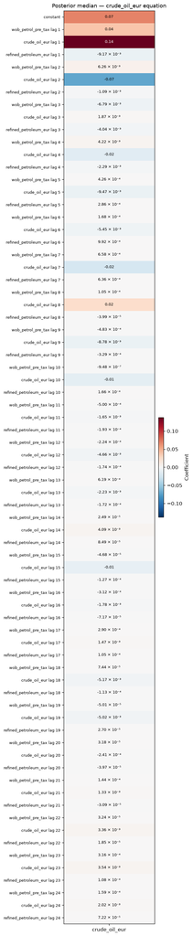

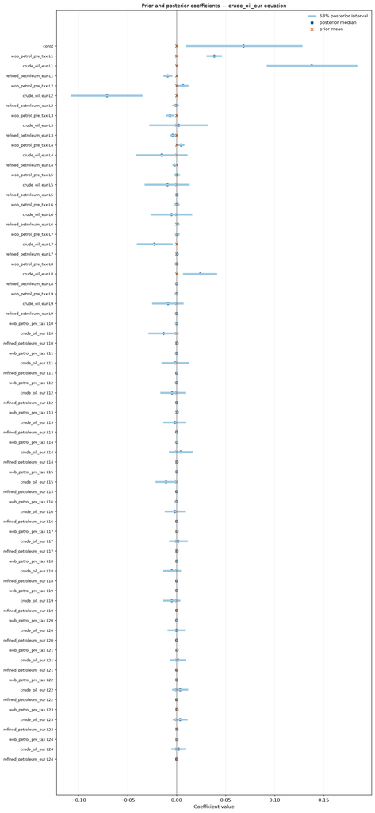

```
refined_petroleum_eur equation
```

Posterior coefficients — refined_petroleum_eur equation

| regressor | prior_mean | prior_sd | posterior_mean | posterior_median | posterior_sd | q05 | q16 | q84 | q95 | ESS |
| --- | --- | --- | --- | --- | --- | --- | --- | --- | --- | --- |
| const | 0.00 | 243.45 | 0.80 | 0.80 | 0.56 | -0.13 | 0.23 | 1.36 | 1.73 | 1945.56 |
| wob_petrol_pre_tax L1 | 0.00 | 0.18 | 0.38 | 0.38 | 0.08 | 0.25 | 0.30 | 0.46 | 0.50 | 1860.20 |
| crude_oil_eur L1 | 0.00 | 0.96 | 1.00 | 1.01 | 0.43 | 0.29 | 0.59 | 1.43 | 1.71 | 1674.54 |
| refined_petroleum_eur L1 | 0.00 | 0.20 | -0.02 | -0.02 | 0.05 | -0.09 | -0.06 | 0.03 | 0.06 | 1383.01 |
| wob_petrol_pre_tax L2 | 0.00 | 0.09 | 0.02 | 0.02 | 0.05 | -0.07 | -0.04 | 0.07 | 0.11 | 1900.41 |
| crude_oil_eur L2 | 0.00 | 0.48 | 0.05 | 0.04 | 0.30 | -0.44 | -0.26 | 0.35 | 0.54 | 2142.91 |
| refined_petroleum_eur L2 | 0.00 | 0.10 | -0.10 | -0.10 | 0.04 | -0.16 | -0.13 | -0.06 | -0.04 | 1904.11 |
| wob_petrol_pre_tax L3 | 0.00 | 0.06 | 0.04 | 0.04 | 0.04 | -0.03 | -2.37 × 10⁻³ | 0.08 | 0.11 | 2566.67 |
| crude_oil_eur L3 | 0.00 | 0.32 | 0.34 | 0.33 | 0.24 | -0.06 | 0.10 | 0.57 | 0.73 | 1603.92 |
| refined_petroleum_eur L3 | 0.00 | 0.07 | -0.09 | -0.09 | 0.03 | -0.14 | -0.12 | -0.06 | -0.04 | 2076.24 |
| wob_petrol_pre_tax L4 | 0.00 | 0.04 | -0.05 | -0.05 | 0.03 | -0.10 | -0.08 | -0.02 | 5.57 × 10⁻³ | 2437.55 |
| crude_oil_eur L4 | 0.00 | 0.24 | -0.14 | -0.14 | 0.19 | -0.45 | -0.33 | 0.06 | 0.18 | 2080.08 |
| refined_petroleum_eur L4 | 0.00 | 0.05 | 0.03 | 0.03 | 0.03 | -0.01 | 1.20 × 10⁻³ | 0.05 | 0.07 | 2216.94 |
| wob_petrol_pre_tax L5 | 0.00 | 0.04 | -0.01 | -0.01 | 0.03 | -0.06 | -0.04 | 0.01 | 0.03 | 2504.82 |
| crude_oil_eur L5 | 0.00 | 0.19 | 1.26 × 10⁻³ | -1.26 × 10⁻³ | 0.16 | -0.27 | -0.16 | 0.16 | 0.28 | 2304.24 |
| refined_petroleum_eur L5 | 0.00 | 0.04 | -3.87 × 10⁻⁴ | -9.60 × 10⁻⁴ | 0.02 | -0.04 | -0.02 | 0.02 | 0.04 | 2177.55 |
| wob_petrol_pre_tax L6 | 0.00 | 0.03 | 0.02 | 0.02 | 0.02 | -0.03 | -9.21 × 10⁻³ | 0.04 | 0.06 | 2672.74 |
| crude_oil_eur L6 | 0.00 | 0.16 | 0.09 | 0.08 | 0.14 | -0.14 | -0.05 | 0.22 | 0.31 | 2397.76 |
| refined_petroleum_eur L6 | 0.00 | 0.03 | -1.57 × 10⁻³ | -1.54 × 10⁻³ | 0.02 | -0.04 | -0.02 | 0.02 | 0.03 | 2235.89 |
| wob_petrol_pre_tax L7 | 0.00 | 0.03 | 8.94 × 10⁻³ | 8.01 × 10⁻³ | 0.02 | -0.03 | -0.01 | 0.03 | 0.05 | 2796.75 |
| crude_oil_eur L7 | 0.00 | 0.14 | 0.03 | 0.04 | 0.12 | -0.17 | -0.08 | 0.16 | 0.23 | 2820.38 |
| refined_petroleum_eur L7 | 0.00 | 0.03 | -0.02 | -0.02 | 0.02 | -0.05 | -0.04 | -2.37 × 10⁻³ | 9.42 × 10⁻³ | 2459.38 |
| wob_petrol_pre_tax L8 | 0.00 | 0.02 | 5.79 × 10⁻³ | 5.60 × 10⁻³ | 0.02 | -0.03 | -0.01 | 0.03 | 0.04 | 2296.21 |
| crude_oil_eur L8 | 0.00 | 0.12 | -0.06 | -0.06 | 0.11 | -0.24 | -0.17 | 0.05 | 0.12 | 2861.54 |
| refined_petroleum_eur L8 | 0.00 | 0.03 | -5.11 × 10⁻³ | -5.28 × 10⁻³ | 0.02 | -0.03 | -0.02 | 0.01 | 0.02 | 2592.49 |
| wob_petrol_pre_tax L9 | 0.00 | 0.02 | -0.01 | -0.01 | 0.02 | -0.04 | -0.03 | 6.37 × 10⁻³ | 0.02 | 2512.34 |
| crude_oil_eur L9 | 0.00 | 0.11 | -0.02 | -0.02 | 0.10 | -0.17 | -0.11 | 0.08 | 0.14 | 2805.19 |
| refined_petroleum_eur L9 | 0.00 | 0.02 | 0.02 | 0.02 | 0.02 | -5.58 × 10⁻³ | 5.21 × 10⁻³ | 0.04 | 0.05 | 1659.13 |
| wob_petrol_pre_tax L10 | 0.00 | 0.02 | -5.56 × 10⁻³ | -5.59 × 10⁻³ | 0.02 | -0.03 | -0.02 | 0.01 | 0.02 | 2897.98 |
| crude_oil_eur L10 | 0.00 | 0.10 | 3.35 × 10⁻³ | 4.66 × 10⁻³ | 0.09 | -0.15 | -0.08 | 0.09 | 0.15 | 2928.51 |
| refined_petroleum_eur L10 | 0.00 | 0.02 | -5.82 × 10⁻³ | -5.89 × 10⁻³ | 0.01 | -0.03 | -0.02 | 8.44 × 10⁻³ | 0.02 | 2513.12 |
| wob_petrol_pre_tax L11 | 0.00 | 0.02 | 2.24 × 10⁻⁴ | -2.27 × 10⁻⁵ | 0.02 | -0.03 | -0.01 | 0.02 | 0.03 | 2653.76 |
| crude_oil_eur L11 | 0.00 | 0.09 | 9.56 × 10⁻⁴ | -5.24 × 10⁻⁴ | 0.08 | -0.14 | -0.08 | 0.08 | 0.14 | 2340.21 |
| refined_petroleum_eur L11 | 0.00 | 0.02 | -0.01 | -0.01 | 0.01 | -0.03 | -0.02 | 2.96 × 10⁻³ | 0.01 | 2821.58 |
| wob_petrol_pre_tax L12 | 0.00 | 0.01 | -4.53 × 10⁻³ | -4.61 × 10⁻³ | 0.01 | -0.03 | -0.02 | 9.23 × 10⁻³ | 0.02 | 2477.85 |
| crude_oil_eur L12 | 0.00 | 0.08 | 6.47 × 10⁻³ | 6.20 × 10⁻³ | 0.07 | -0.12 | -0.07 | 0.08 | 0.13 | 2562.37 |
| refined_petroleum_eur L12 | 0.00 | 0.02 | -6.46 × 10⁻³ | -6.69 × 10⁻³ | 0.01 | -0.03 | -0.02 | 6.03 × 10⁻³ | 0.01 | 2310.36 |
| wob_petrol_pre_tax L13 | 0.00 | 0.01 | -5.51 × 10⁻³ | -5.46 × 10⁻³ | 0.01 | -0.03 | -0.02 | 7.24 × 10⁻³ | 0.01 | 2742.03 |
| crude_oil_eur L13 | 0.00 | 0.07 | -0.01 | -0.01 | 0.07 | -0.13 | -0.08 | 0.06 | 0.10 | 2677.79 |
| refined_petroleum_eur L13 | 0.00 | 0.02 | 5.53 × 10⁻⁴ | 4.83 × 10⁻⁴ | 0.01 | -0.02 | -0.01 | 0.01 | 0.02 | 2229.13 |
| wob_petrol_pre_tax L14 | 0.00 | 0.01 | -5.87 × 10⁻³ | -5.72 × 10⁻³ | 0.01 | -0.03 | -0.02 | 6.09 × 10⁻³ | 0.01 | 3000.00 |
| crude_oil_eur L14 | 0.00 | 0.07 | -0.01 | -0.01 | 0.06 | -0.12 | -0.08 | 0.05 | 0.09 | 2813.23 |
| refined_petroleum_eur L14 | 0.00 | 0.01 | -6.95 × 10⁻³ | -6.63 × 10⁻³ | 0.01 | -0.03 | -0.02 | 4.31 × 10⁻³ | 0.01 | 2181.57 |
| wob_petrol_pre_tax L15 | 0.00 | 0.01 | -2.77 × 10⁻³ | -2.84 × 10⁻³ | 0.01 | -0.02 | -0.01 | 8.40 × 10⁻³ | 0.02 | 2838.89 |
| crude_oil_eur L15 | 0.00 | 0.06 | 0.03 | 0.03 | 0.06 | -0.08 | -0.04 | 0.09 | 0.13 | 2518.90 |
| refined_petroleum_eur L15 | 0.00 | 0.01 | -3.76 × 10⁻³ | -3.88 × 10⁻³ | 0.01 | -0.02 | -0.01 | 7.23 × 10⁻³ | 0.01 | 1944.10 |
| wob_petrol_pre_tax L16 | 0.00 | 0.01 | 4.75 × 10⁻⁴ | 3.67 × 10⁻⁴ | 0.01 | -0.02 | -0.01 | 0.01 | 0.02 | 2945.27 |
| crude_oil_eur L16 | 0.00 | 0.06 | -5.02 × 10⁻³ | -4.74 × 10⁻³ | 0.06 | -0.10 | -0.06 | 0.05 | 0.09 | 2794.67 |
| refined_petroleum_eur L16 | 0.00 | 0.01 | -8.21 × 10⁻³ | -8.10 × 10⁻³ | 0.01 | -0.03 | -0.02 | 1.85 × 10⁻³ | 8.17 × 10⁻³ | 2471.58 |
| wob_petrol_pre_tax L17 | 0.00 | 0.01 | -1.90 × 10⁻³ | -2.09 × 10⁻³ | 9.93 × 10⁻³ | -0.02 | -0.01 | 8.42 × 10⁻³ | 0.01 | 2934.34 |
| crude_oil_eur L17 | 0.00 | 0.06 | 2.49 × 10⁻³ | 2.35 × 10⁻³ | 0.05 | -0.08 | -0.05 | 0.06 | 0.09 | 2782.39 |
| refined_petroleum_eur L17 | 0.00 | 0.01 | 8.84 × 10⁻⁴ | 8.41 × 10⁻⁴ | 9.82 × 10⁻³ | -0.02 | -8.64 × 10⁻³ | 0.01 | 0.02 | 2558.77 |
| wob_petrol_pre_tax L18 | 0.00 | 9.81 × 10⁻³ | -1.70 × 10⁻³ | -1.67 × 10⁻³ | 9.36 × 10⁻³ | -0.02 | -0.01 | 7.43 × 10⁻³ | 0.01 | 3000.00 |
| crude_oil_eur L18 | 0.00 | 0.05 | 6.99 × 10⁻³ | 7.95 × 10⁻³ | 0.05 | -0.08 | -0.04 | 0.06 | 0.09 | 3000.00 |
| refined_petroleum_eur L18 | 0.00 | 0.01 | 3.92 × 10⁻⁴ | 2.78 × 10⁻⁴ | 9.38 × 10⁻³ | -0.01 | -8.87 × 10⁻³ | 9.99 × 10⁻³ | 0.02 | 2723.29 |
| wob_petrol_pre_tax L19 | 0.00 | 9.29 × 10⁻³ | -4.46 × 10⁻³ | -4.48 × 10⁻³ | 8.95 × 10⁻³ | -0.02 | -0.01 | 4.38 × 10⁻³ | 0.01 | 2937.39 |
| crude_oil_eur L19 | 0.00 | 0.05 | 1.08 × 10⁻³ | 5.66 × 10⁻⁴ | 0.05 | -0.08 | -0.05 | 0.05 | 0.08 | 3000.00 |
| refined_petroleum_eur L19 | 0.00 | 0.01 | -9.85 × 10⁻³ | -9.84 × 10⁻³ | 8.86 × 10⁻³ | -0.02 | -0.02 | -1.08 × 10⁻³ | 4.60 × 10⁻³ | 2474.17 |
| wob_petrol_pre_tax L20 | 0.00 | 8.83 × 10⁻³ | 1.85 × 10⁻⁴ | 2.35 × 10⁻⁴ | 8.23 × 10⁻³ | -0.01 | -7.89 × 10⁻³ | 8.20 × 10⁻³ | 0.01 | 2841.23 |
| crude_oil_eur L20 | 0.00 | 0.05 | -2.97 × 10⁻³ | -4.27 × 10⁻³ | 0.05 | -0.08 | -0.05 | 0.04 | 0.07 | 2583.06 |
| refined_petroleum_eur L20 | 0.00 | 0.01 | -1.11 × 10⁻³ | -1.12 × 10⁻³ | 8.53 × 10⁻³ | -0.01 | -9.38 × 10⁻³ | 7.27 × 10⁻³ | 0.01 | 2657.67 |
| wob_petrol_pre_tax L21 | 0.00 | 8.41 × 10⁻³ | -1.42 × 10⁻³ | -1.35 × 10⁻³ | 8.00 × 10⁻³ | -0.01 | -9.35 × 10⁻³ | 6.42 × 10⁻³ | 0.01 | 2683.70 |
| crude_oil_eur L21 | 0.00 | 0.05 | -8.04 × 10⁻⁴ | 1.54 × 10⁻⁵ | 0.04 | -0.07 | -0.05 | 0.04 | 0.07 | 2888.81 |
| refined_petroleum_eur L21 | 0.00 | 9.52 × 10⁻³ | -1.03 × 10⁻³ | -1.04 × 10⁻³ | 8.17 × 10⁻³ | -0.01 | -8.90 × 10⁻³ | 6.86 × 10⁻³ | 0.01 | 2653.57 |
| wob_petrol_pre_tax L22 | 0.00 | 8.03 × 10⁻³ | -2.79 × 10⁻⁴ | -4.35 × 10⁻⁴ | 7.99 × 10⁻³ | -0.01 | -8.36 × 10⁻³ | 7.86 × 10⁻³ | 0.01 | 2855.35 |
| crude_oil_eur L22 | 0.00 | 0.04 | -7.96 × 10⁻³ | -8.16 × 10⁻³ | 0.04 | -0.08 | -0.05 | 0.04 | 0.06 | 2606.50 |
| refined_petroleum_eur L22 | 0.00 | 9.09 × 10⁻³ | -3.04 × 10⁻³ | -3.04 × 10⁻³ | 7.93 × 10⁻³ | -0.02 | -0.01 | 4.77 × 10⁻³ | 9.94 × 10⁻³ | 2946.26 |
| wob_petrol_pre_tax L23 | 0.00 | 7.68 × 10⁻³ | -4.08 × 10⁻³ | -4.13 × 10⁻³ | 7.31 × 10⁻³ | -0.02 | -0.01 | 3.01 × 10⁻³ | 7.73 × 10⁻³ | 2772.59 |
| crude_oil_eur L23 | 0.00 | 0.04 | -4.18 × 10⁻³ | -4.61 × 10⁻³ | 0.04 | -0.07 | -0.05 | 0.04 | 0.06 | 2564.97 |
| refined_petroleum_eur L23 | 0.00 | 8.70 × 10⁻³ | -4.35 × 10⁻³ | -4.41 × 10⁻³ | 7.74 × 10⁻³ | -0.02 | -0.01 | 3.26 × 10⁻³ | 8.44 × 10⁻³ | 2456.83 |
| wob_petrol_pre_tax L24 | 0.00 | 7.36 × 10⁻³ | -2.46 × 10⁻³ | -2.43 × 10⁻³ | 7.33 × 10⁻³ | -0.01 | -9.63 × 10⁻³ | 4.68 × 10⁻³ | 9.47 × 10⁻³ | 2539.51 |
| crude_oil_eur L24 | 0.00 | 0.04 | 5.47 × 10⁻⁴ | -6.54 × 10⁻⁶ | 0.04 | -0.06 | -0.04 | 0.04 | 0.06 | 2943.97 |
| refined_petroleum_eur L24 | 0.00 | 8.33 × 10⁻³ | -5.35 × 10⁻³ | -5.24 × 10⁻³ | 7.59 × 10⁻³ | -0.02 | -0.01 | 2.09 × 10⁻³ | 7.15 × 10⁻³ | 2561.04 |

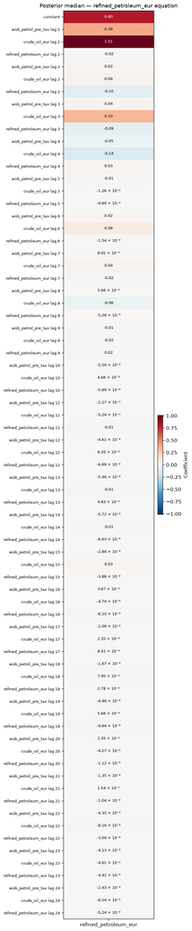

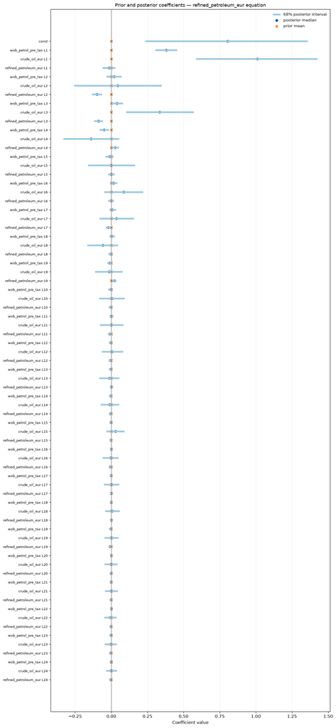

```python
coefficient_tables = coefficient_posterior_tables(result)
for equation in VARIABLES:
    print()
    print(f"{equation} equation")
    display(style_numeric_table(
        coefficient_tables[equation],
        caption=f"Posterior coefficients — {equation} equation",
    ))
    plot_coefficient_heatmap(result, equation=equation)
    plot_shrinkage_comparison(result, equations=[equation])
    plt.show()
```

MCMC diagnostics

|  | posterior_mean | posterior_sd | ESS | MCSE_mean | MCSE_over_sd |
| --- | --- | --- | --- | --- | --- |
| log likelihood | -8108.39 | 19.03 | 224.14 | 1.27 | 0.07 |
| spectral radius | 0.88 | 8.45 × 10⁻³ | 2951.80 | 1.56 × 10⁻⁴ | 0.02 |
| A[crude_oil_eur,wob_petrol_pre_tax] | -0.14 | 5.56 × 10⁻³ | 733.72 | 2.05 × 10⁻⁴ | 0.04 |
| phi[wob_petrol_pre_tax] | 0.02 | 7.59 × 10⁻³ | 23.28 | 1.57 × 10⁻³ | 0.21 |
| p_outlier[wob_petrol_pre_tax] | 0.02 | 5.47 × 10⁻³ | 185.32 | 4.02 × 10⁻⁴ | 0.07 |
| own L1[wob_petrol_pre_tax] | 0.18 | 0.04 | 1527.85 | 1.06 × 10⁻³ | 0.03 |
| phi[crude_oil_eur] | 0.03 | 8.51 × 10⁻³ | 30.60 | 1.54 × 10⁻³ | 0.18 |
| p_outlier[crude_oil_eur] | 5.85 × 10⁻³ | 3.56 × 10⁻³ | 194.95 | 2.55 × 10⁻⁴ | 0.07 |
| own L1[crude_oil_eur] | 0.14 | 0.05 | 2065.41 | 1.02 × 10⁻³ | 0.02 |
| phi[refined_petroleum_eur] | 0.04 | 0.01 | 25.68 | 2.40 × 10⁻³ | 0.20 |
| p_outlier[refined_petroleum_eur] | 0.02 | 5.62 × 10⁻³ | 322.98 | 3.13 × 10⁻⁴ | 0.06 |
| own L1[refined_petroleum_eur] | -0.02 | 0.05 | 1383.01 | 1.22 × 10⁻³ | 0.03 |

VAR stability diagnostics

|  | value |
| --- | --- |
| retained_draws | 3000.00 |
| median_spectral_radius | 0.88 |
| q95_spectral_radius | 0.90 |
| maximum_spectral_radius | 0.92 |
| retained_unstable_share | 0.00 |
| B_total_proposals | 6000.00 |
| B_unstable_proposals | 0.00 |
| B_instability_rejection_rate | 0.00 |

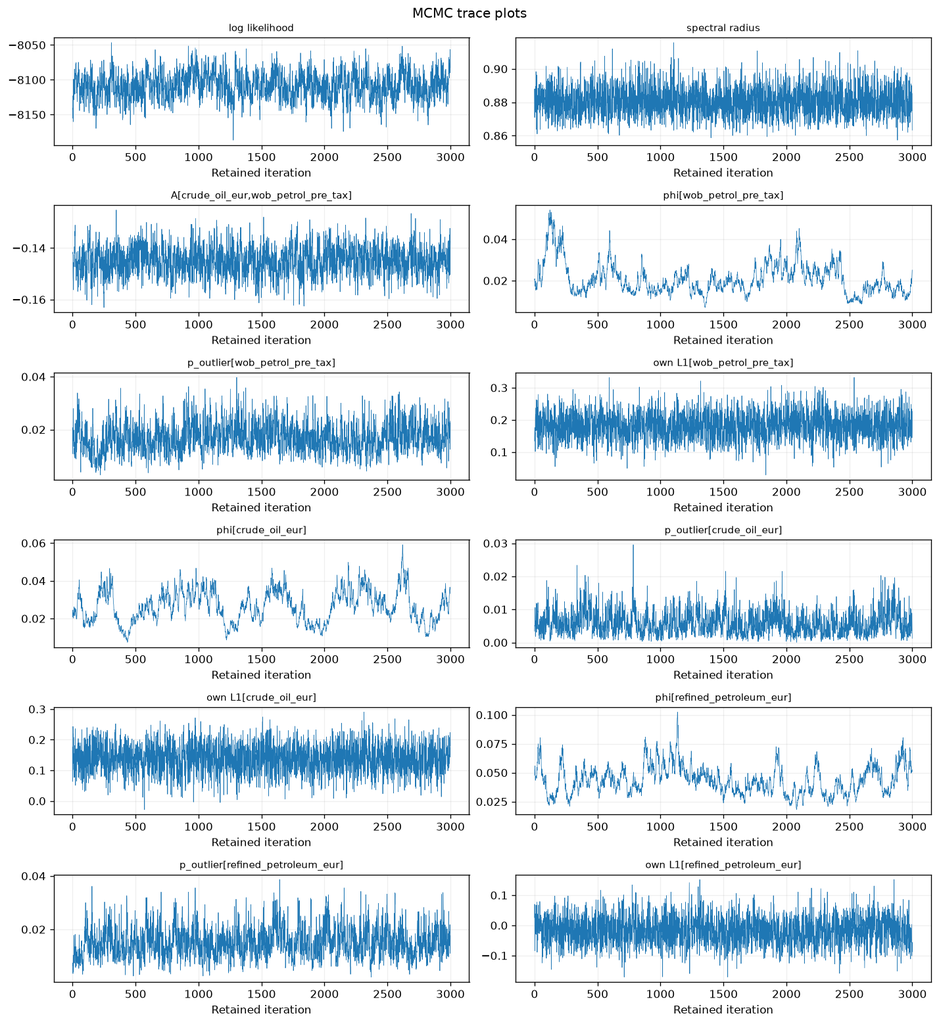

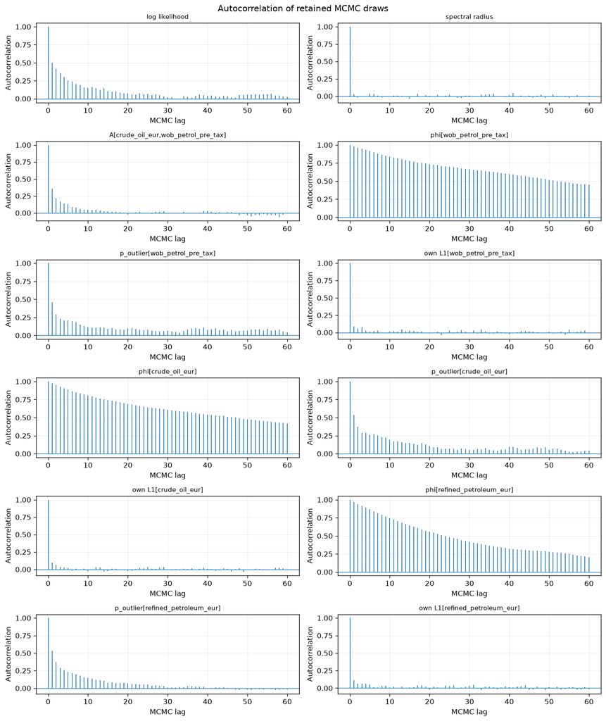

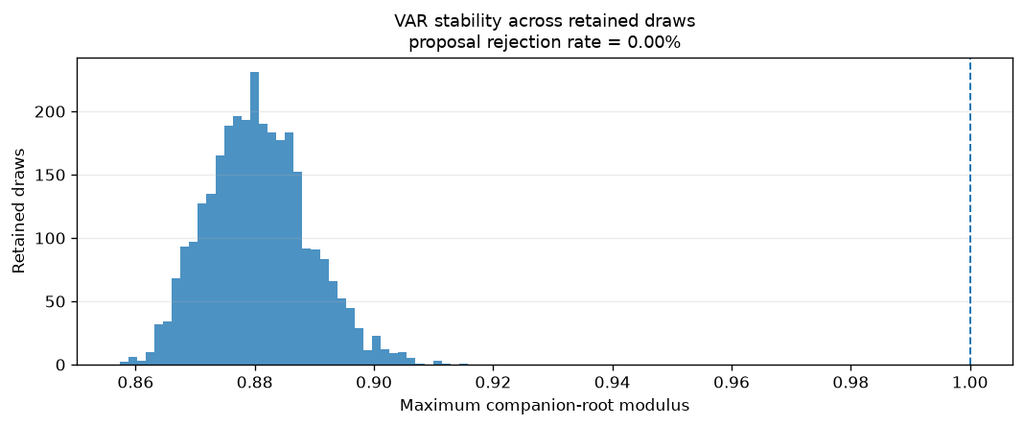

```python
display(style_numeric_table(
    mcmc_diagnostics(result),
    caption="MCMC diagnostics",
))
display(style_numeric_table(
    stability_diagnostics(result).to_frame("value"),
    caption="VAR stability diagnostics",
))
plot_trace_grid(result)
plt.show()
plot_chain_acf_grid(result, nlags=60)
plt.show()
plot_spectral_radius(result)
plt.show()
```

Largest posterior outlier probabilities

| date | wob_petrol_pre_tax | crude_oil_eur | refined_petroleum_eur |
| --- | --- | --- | --- |
| 2020-03-16 | 0.95 | 0.44 | 0.02 |
| 2022-03-21 | 0.95 | 2.00 × 10⁻³ | 2.33 × 10⁻³ |
| 2022-03-14 | 0.95 | 0.41 | 3.67 × 10⁻³ |
| 2013-04-08 | 0.93 | 0.02 | 3.67 × 10⁻³ |
| 2026-03-09 | 0.93 | 1.00 × 10⁻³ | 4.00 × 10⁻³ |
| 2022-03-07 | 0.92 | 3.33 × 10⁻⁴ | 0.13 |
| 2014-10-20 | 0.87 | 3.33 × 10⁻⁴ | 3.33 × 10⁻³ |
| 2013-04-01 | 0.80 | 0.12 | 0.07 |
| 2022-06-06 | 0.74 | 9.67 × 10⁻³ | 3.67 × 10⁻³ |
| 2020-03-02 | 0.56 | 1.67 × 10⁻³ | 2.33 × 10⁻³ |
| 2015-02-09 | 0.40 | 4.67 × 10⁻³ | 6.67 × 10⁻⁴ |
| 2016-02-15 | 0.21 | 1.67 × 10⁻³ | 3.00 × 10⁻³ |
| 2022-12-12 | 0.19 | 1.33 × 10⁻³ | 2.67 × 10⁻³ |
| 2014-12-08 | 0.18 | 3.33 × 10⁻⁴ | 7.33 × 10⁻³ |
| 2019-06-10 | 0.17 | 1.67 × 10⁻³ | 0.72 |

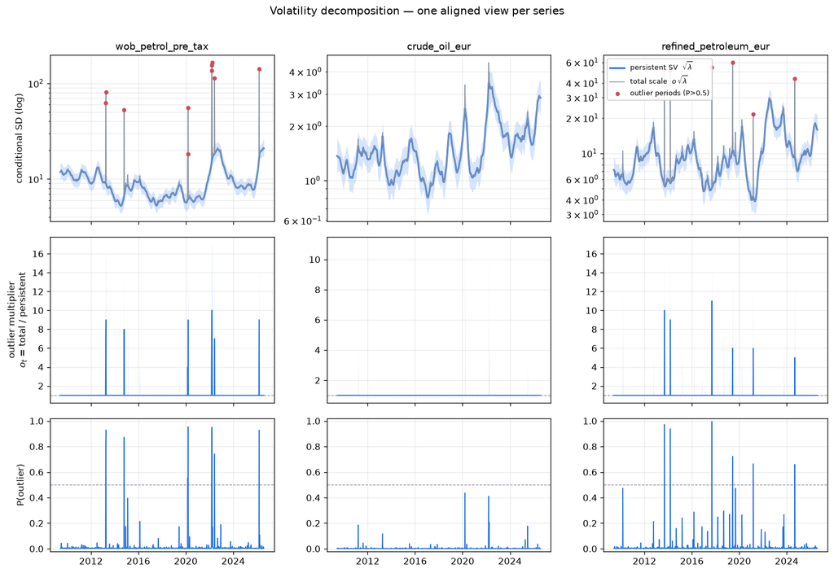

Standardized structural-residual diagnostics

| variable | mean | sd | skewness | excess_kurtosis | acf_1 | maximum_absolute |
| --- | --- | --- | --- | --- | --- | --- |
| wob_petrol_pre_tax | -8.24 × 10⁻³ | 0.98 | -0.13 | -0.09 | 0.04 | 3.28 |
| crude_oil_eur | -0.02 | 0.98 | -0.20 | 0.19 | -0.03 | 3.64 |
| refined_petroleum_eur | -2.27 × 10⁻³ | 0.98 | -0.28 | 0.36 | -0.01 | 3.44 |

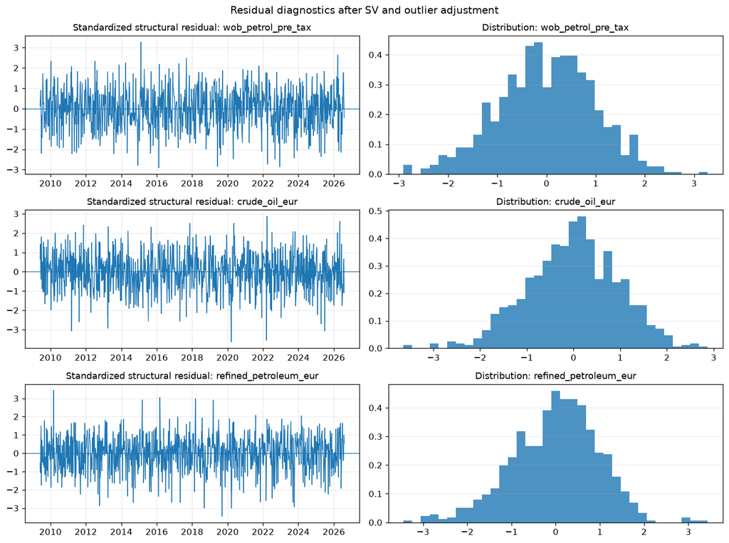

```python
outlier_probability = posterior_outlier_probability(result)
display(style_numeric_table(
    outlier_probability.sort_values(TARGET, ascending=False).head(15),
    caption="Largest posterior outlier probabilities",
))
plot_volatility_decomposition(result)
plt.show()

display(style_numeric_table(
    residual_diagnostic_table(result),
    caption="Standardized structural-residual diagnostics",
))
plot_standardized_residuals(result)
plt.show()
```

Posterior predictive checks

|  | observed | replicated_median | replicated_q05 | replicated_q95 |
| --- | --- | --- | --- | --- |
| wob_petrol_pre_tax: mean | 0.62 | 0.74 | -1.78 | 2.87 |
| wob_petrol_pre_tax: sd | 14.95 | 20.74 | 15.22 | 31.57 |
| wob_petrol_pre_tax: maximum_absolute | 147.23 | 302.34 | 140.04 | 622.77 |
| crude_oil_eur: mean | 0.04 | 0.08 | -0.18 | 0.35 |
| crude_oil_eur: sd | 2.56 | 3.43 | 2.70 | 5.11 |
| crude_oil_eur: maximum_absolute | 17.23 | 47.16 | 23.67 | 94.41 |
| refined_petroleum_eur: mean | 0.52 | 0.88 | -1.80 | 3.38 |
| refined_petroleum_eur: sd | 24.94 | 34.76 | 27.20 | 50.03 |
| refined_petroleum_eur: maximum_absolute | 139.61 | 486.71 | 234.49 | 897.58 |

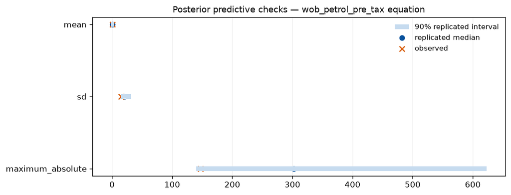

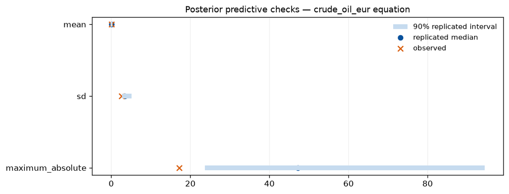

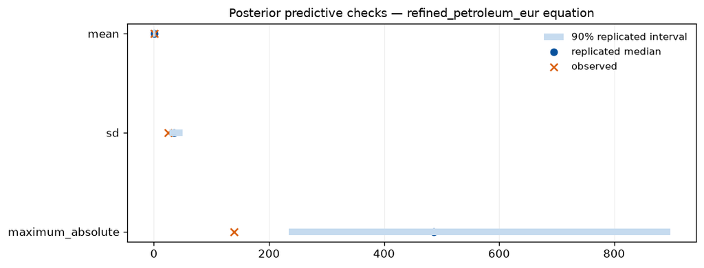

Stationarity tests on balanced weekly changes

| variable | ADF statistic | ADF p-value | ADF lags | KPSS statistic | KPSS p-value | KPSS lags | observations |
| --- | --- | --- | --- | --- | --- | --- | --- |
| wob_petrol_pre_tax | -13.89 | 6.04 × 10⁻²⁶ | 2.00 | 0.07 | 0.10 | 11.00 | 918.00 |
| crude_oil_eur | -9.50 | 3.49 × 10⁻¹⁶ | 12.00 | 0.07 | 0.10 | 2.00 | 908.00 |
| refined_petroleum_eur | -24.51 | 0.00 | 0.00 | 0.05 | 0.10 | 8.00 | 920.00 |

```python
ppc_summary, ppc_draws = posterior_predictive_statistics(
    result,
    n_draws=PPC_DRAWS,
    seed=456,
)
display(style_numeric_table(
    ppc_summary,
    caption="Posterior predictive checks",
))
for equation in VARIABLES:
    plot_posterior_predictive_check(ppc_summary, equation=equation)
    plt.show()

display(style_numeric_table(
    stationarity_tests(prep["balanced"]),
    caption="Stationarity tests on balanced weekly changes",
))
```

## 6. Ragged-edge nowcast and weekly forecast

Ragged-edge petrol nowcast

| date | status | observed | q05 | q16 | median | q84 | q95 |
| --- | --- | --- | --- | --- | --- | --- | --- |
| 2026-08-10 | nowcast | — | 927.11 | 939.57 | 962.94 | 980.78 | 993.03 |

Weekly petrol pre-tax forecast

| horizon | weeks_ahead | target_date | q05 | q16 | median | q84 | q95 |
| --- | --- | --- | --- | --- | --- | --- | --- |
| 1 week | 1.00 | 2026-08-17 | 877.84 | 906.05 | 941.44 | 971.48 | 988.20 |
| 4 weeks | 4.00 | 2026-09-07 | 785.24 | 841.95 | 925.67 | 992.28 | 1048.94 |
| 13 weeks | 13.00 | 2026-11-09 | 569.59 | 729.35 | 922.68 | 1095.67 | 1245.34 |
| 26 weeks | 26.00 | 2027-02-08 | 329.61 | 642.09 | 937.87 | 1226.10 | 1568.05 |

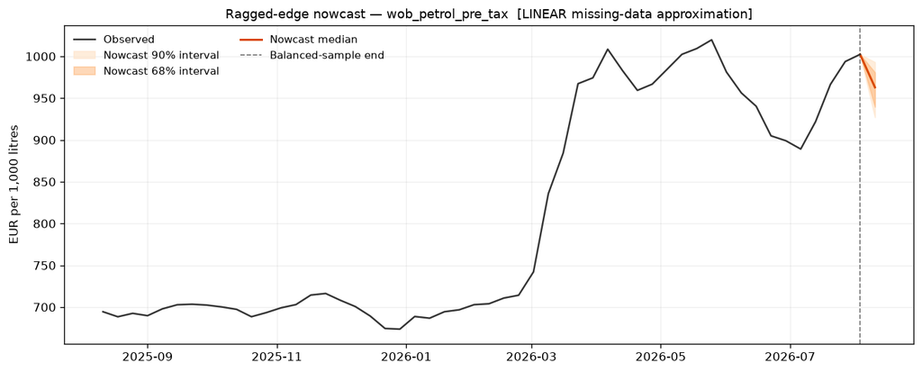

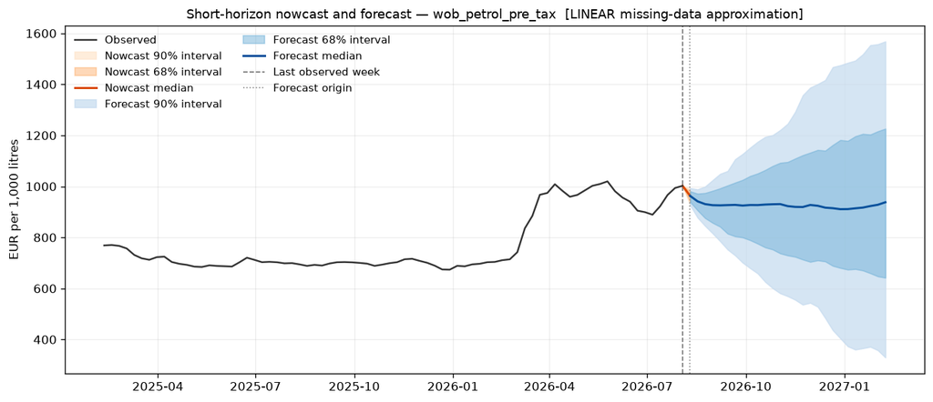

```
Saved unconditional forecast store: C:\Users\kelyan.gane\Project\Python\Bayesian_model\bvar-energy\results\car_fuels_petrol\20260808\dbb24005d734a7b037d2d885c5354ecee24101c76dca22b2acc8ef4e586e0137\forecasts\unconditional
```

```python
forecast_unconditional = forecast_bvar_sv_outlier(
    result,
    H=FORECAST_H,
    n_draws=FORECAST_DRAWS,
    simulate_future_outliers=SIMULATE_FUTURE_OUTLIERS,
    seed=123,
)

display(style_numeric_table(
    nowcast_summary_table(
        forecast_unconditional,
        observed_levels=levels,
        variable=TARGET,
    ),
    caption="Ragged-edge petrol nowcast",
))
display(style_numeric_table(
    weekly_forecast_horizon_table(
        forecast_unconditional,
        TARGET,
        horizons=(1, 4, 13, 26),
    ),
    caption="Weekly petrol pre-tax forecast",
))

plot_nowcast_fan(
    forecast_unconditional,
    levels,
    TARGET,
    last_obs=52,
    ylabel=UNITS[TARGET],
)
plt.show()
plot_short_forecast_fan(
    forecast_unconditional,
    levels,
    TARGET,
    last_obs=78,
    ylabel=UNITS[TARGET],
)
plt.show()

if SAVE_FORECASTS:
    saved_forecast_paths = save_energy_bvar_forecast_for_result(
        forecast_unconditional,
        result,
        RESULTS_ROOT,
        "unconditional",
    )
    print(f"Saved unconditional forecast store: {saved_forecast_paths['directory']}")
```

## 7. Conditional commodity-price scenarios

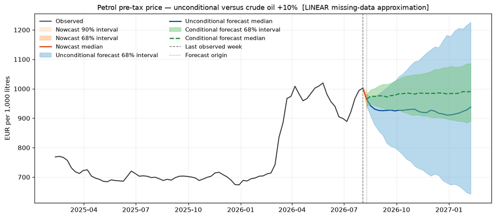

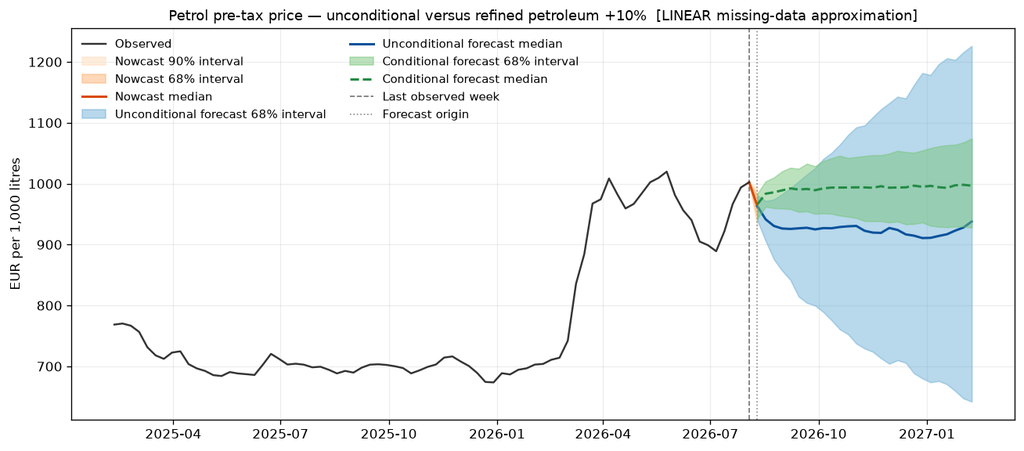

```python
last_crude = float(levels["crude_oil_eur"].dropna().iloc[-1])
last_refined = float(levels["refined_petroleum_eur"].dropna().iloc[-1])
crude_up_10 = np.full(FORECAST_H, 1.10 * last_crude)
refined_up_10 = np.full(FORECAST_H, 1.10 * last_refined)

forecast_crude_up_10 = forecast_bvar_sv_outlier(
    result,
    H=FORECAST_H,
    level_conditions={"crude_oil_eur": crude_up_10},
    n_draws=FORECAST_DRAWS,
    simulate_future_outliers=SIMULATE_FUTURE_OUTLIERS,
    seed=123,
)
forecast_refined_up_10 = forecast_bvar_sv_outlier(
    result,
    H=FORECAST_H,
    level_conditions={"refined_petroleum_eur": refined_up_10},
    n_draws=FORECAST_DRAWS,
    simulate_future_outliers=SIMULATE_FUTURE_OUTLIERS,
    seed=123,
)

plot_forecast_comparison(
    forecast_unconditional,
    forecast_crude_up_10,
    levels,
    TARGET,
    last_obs=78,
    title="Petrol pre-tax price — unconditional versus crude oil +10%",
    ylabel=UNITS[TARGET],
)
plt.show()
plot_forecast_comparison(
    forecast_unconditional,
    forecast_refined_up_10,
    levels,
    TARGET,
    last_obs=78,
    title="Petrol pre-tax price — unconditional versus refined petroleum +10%",
    ylabel=UNITS[TARGET],
)
plt.show()
```